# Part I - (Flights and performance)

## Introduction

This document explores a dataset that has data about flights covered by several airlines/carriers across several cities in the US. Since the dataset is very large (nearly 120 million records in total, and takes up 1.6 gigabytes of space compressed and 12 gigabytes when uncompressed). Because of the size of the dataset, for this project, I am only using a segment of the data, so I selected all the data for December 2019 and December 2020.

## Preliminary Wrangling

```python
# import all packages and set plots to be embedded inline
import numpy as np
import pandas as pd
import matplotlib.pyplot as plt
import seaborn as sb

%matplotlib inline
```

```python
#extract December 2019 flight data and store in a dataframe
df_flights_12_2019 = pd.read_csv('Flights_12_2019.csv')
```

```python
#Check few rows of dataframe to confirm data was copied
df_flights_12_2019.head()
```

|  |  | QUARTER | MONTH | DAY_OF_MONTH | DAY_OF_WEEK | FL_DATE | OP_UNIQUE_CARRIER | OP_CARRIER_AIRLINE_ID | OP_CARRIER | TAIL_NUM | ... | DIV1_WHEELS_OFF | DIV1_TAIL_NUM | DIV2_AIRPORT | DIV2_AIRPORT_ID | DIV2_AIRPORT_SEQ_ID | DIV2_WHEELS_ON | DIV2_TOTAL_GTIME | DIV2_LONGEST_GTIME | DIV2_WHEELS_OFF | DIV2_TAIL_NUM |
| --- | --- | --- | --- | --- | --- | --- | --- | --- | --- | --- | --- | --- | --- | --- | --- | --- | --- | --- | --- | --- | --- |
| 0 | 2019 | 4 | 12 | 9 | 1 | 12/9/2019 | YX | 20452 | YX | N117HQ | ... | NaN | NaN | NaN | NaN | NaN | NaN | NaN | NaN | NaN | NaN |
| 1 | 2019 | 4 | 12 | 10 | 2 | 12/10/2019 | YX | 20452 | YX | N131HQ | ... | NaN | NaN | NaN | NaN | NaN | NaN | NaN | NaN | NaN | NaN |
| 2 | 2019 | 4 | 12 | 11 | 3 | 12/11/2019 | YX | 20452 | YX | N108HQ | ... | NaN | NaN | NaN | NaN | NaN | NaN | NaN | NaN | NaN | NaN |
| 3 | 2019 | 4 | 12 | 12 | 4 | 12/12/2019 | YX | 20452 | YX | N111HQ | ... | NaN | NaN | NaN | NaN | NaN | NaN | NaN | NaN | NaN | NaN |
| 4 | 2019 | 4 | 12 | 13 | 5 | 12/13/2019 | YX | 20452 | YX | N136HQ | ... | NaN | NaN | NaN | NaN | NaN | NaN | NaN | NaN | NaN | NaN |

5 rows × 85 columns

```python
#Check datatypes of columns
df_flights_12_2019.info()
```

```
<class 'pandas.core.frame.DataFrame'>
RangeIndex: 625763 entries, 0 to 625762
Data columns (total 85 columns):
 #   Column                   Non-Null Count   Dtype
---  ------                   --------------   -----
 0                            625763 non-null  int64
 1   QUARTER                  625763 non-null  int64
 2   MONTH                    625763 non-null  int64
 3   DAY_OF_MONTH             625763 non-null  int64
 4   DAY_OF_WEEK              625763 non-null  int64
 5   FL_DATE                  625763 non-null  object
 6   OP_UNIQUE_CARRIER        625763 non-null  object
 7   OP_CARRIER_AIRLINE_ID    625763 non-null  int64
 8   OP_CARRIER               625763 non-null  object
 9   TAIL_NUM                 625306 non-null  object
```

[output cut: 77 more lines]

```python
#Look for columns with nulls
df_flights_12_2019.isnull().sum()
```

```
                           0
QUARTER                    0
MONTH                      0
DAY_OF_MONTH               0
DAY_OF_WEEK                0
                       ...
DIV2_WHEELS_ON        625740
DIV2_TOTAL_GTIME      625740
DIV2_LONGEST_GTIME    625740
DIV2_WHEELS_OFF       625755
DIV2_TAIL_NUM         625755
Length: 85, dtype: int64
```

```python
#Fill missing data with 0's
df_flights_12_2019 = df_flights_12_2019.fillna(0)
```

```python
#Confirm nulls/NaN have been replaced with 0's
df_flights_12_2019.isnull().sum()
```

```
                      0
QUARTER               0
MONTH                 0
DAY_OF_MONTH          0
DAY_OF_WEEK           0
                     ..
DIV2_WHEELS_ON        0
DIV2_TOTAL_GTIME      0
DIV2_LONGEST_GTIME    0
DIV2_WHEELS_OFF       0
DIV2_TAIL_NUM         0
Length: 85, dtype: int64
```

```python
#Check for duplicates
df_flights_12_2019.duplicated()
```

```
0         False
1         False
2         False
3         False
4         False
          ...
625758    False
625759    False
625760    False
625761    False
625762    False
Length: 625763, dtype: bool
```

```python
#Look at a few rows again to confirm that the empty fields have been filled with 0's
df_flights_12_2019.head()
```

|  |  | QUARTER | MONTH | DAY_OF_MONTH | DAY_OF_WEEK | FL_DATE | OP_UNIQUE_CARRIER | OP_CARRIER_AIRLINE_ID | OP_CARRIER | TAIL_NUM | ... | DIV1_WHEELS_OFF | DIV1_TAIL_NUM | DIV2_AIRPORT | DIV2_AIRPORT_ID | DIV2_AIRPORT_SEQ_ID | DIV2_WHEELS_ON | DIV2_TOTAL_GTIME | DIV2_LONGEST_GTIME | DIV2_WHEELS_OFF | DIV2_TAIL_NUM |
| --- | --- | --- | --- | --- | --- | --- | --- | --- | --- | --- | --- | --- | --- | --- | --- | --- | --- | --- | --- | --- | --- |
| 0 | 2019 | 4 | 12 | 9 | 1 | 12/9/2019 | YX | 20452 | YX | N117HQ | ... | 0.0 | 0 | 0 | 0.0 | 0.0 | 0.0 | 0.0 | 0.0 | 0.0 | 0 |
| 1 | 2019 | 4 | 12 | 10 | 2 | 12/10/2019 | YX | 20452 | YX | N131HQ | ... | 0.0 | 0 | 0 | 0.0 | 0.0 | 0.0 | 0.0 | 0.0 | 0.0 | 0 |
| 2 | 2019 | 4 | 12 | 11 | 3 | 12/11/2019 | YX | 20452 | YX | N108HQ | ... | 0.0 | 0 | 0 | 0.0 | 0.0 | 0.0 | 0.0 | 0.0 | 0.0 | 0 |
| 3 | 2019 | 4 | 12 | 12 | 4 | 12/12/2019 | YX | 20452 | YX | N111HQ | ... | 0.0 | 0 | 0 | 0.0 | 0.0 | 0.0 | 0.0 | 0.0 | 0.0 | 0 |
| 4 | 2019 | 4 | 12 | 13 | 5 | 12/13/2019 | YX | 20452 | YX | N136HQ | ... | 0.0 | 0 | 0 | 0.0 | 0.0 | 0.0 | 0.0 | 0.0 | 0.0 | 0 |

5 rows × 85 columns

There are a number of columns which hold data that are related to time - flight times, delays e.t.c, but have the wrong data type, mainly float. The following step converts them to string, since some of the columns have the time in military format. Converting them to integer presented problems, becaise of the decimal points, so I am including the cleaner version of my transformation. Also, I am not doing any calculations on the time values so, it is okay to leave them as string.

```python
#Change the data type of the following columns from float to string to reflect the time correctly
df_flights_12_2019 = df_flights_12_2019.astype({ 'DEP_TIME': 'str','WHEELS_OFF': 'str','WHEELS_ON': 'str',
                                                'ARR_TIME': 'str','ACTUAL_ELAPSED_TIME': 'str','AIR_TIME': 'str','TAXI_IN': 'str',
                                                'FIRST_DEP_TIME': 'str','TOTAL_ADD_GTIME': 'str','LONGEST_ADD_GTIME': 'str',
                                                'DIV_REACHED_DEST': 'str','DIV_ACTUAL_ELAPSED_TIME': 'str',
                                                'DIV1_AIRPORT_ID': 'str','DIV1_AIRPORT_SEQ_ID': 'str','DIV1_WHEELS_ON': 'str','DIV1_TOTAL_GTIME': 'str',
                                                'DIV1_LONGEST_GTIME': 'str','DIV1_WHEELS_OFF': 'str','DIV2_AIRPORT_ID': 'str','DIV2_AIRPORT_SEQ_ID': 'str',
                                                'DIV2_WHEELS_ON': 'str','DIV2_TOTAL_GTIME': 'str','DIV2_LONGEST_GTIME': 'str','DIV2_WHEELS_OFF': 'str'})
```

```python
#Confirm datatypes have changed
df_flights_12_2019.info()
```

```
<class 'pandas.core.frame.DataFrame'>
RangeIndex: 625763 entries, 0 to 625762
Data columns (total 85 columns):
 #   Column                   Non-Null Count   Dtype
---  ------                   --------------   -----
 0                            625763 non-null  int64
 1   QUARTER                  625763 non-null  int64
 2   MONTH                    625763 non-null  int64
 3   DAY_OF_MONTH             625763 non-null  int64
 4   DAY_OF_WEEK              625763 non-null  int64
 5   FL_DATE                  625763 non-null  object
 6   OP_UNIQUE_CARRIER        625763 non-null  object
 7   OP_CARRIER_AIRLINE_ID    625763 non-null  int64
 8   OP_CARRIER               625763 non-null  object
 9   TAIL_NUM                 625763 non-null  object
```

[output cut: 77 more lines]

```python
#Update the data in the columns whose data types were changed above - remove .0 from end of column values
columns_update = ['DEP_TIME','WHEELS_OFF','WHEELS_ON',  'ARR_TIME','ACTUAL_ELAPSED_TIME','AIR_TIME',
                                                'FIRST_DEP_TIME','TOTAL_ADD_GTIME','LONGEST_ADD_GTIME',
                  'DIV_REACHED_DEST','DIV_ACTUAL_ELAPSED_TIME', 'DIV1_AIRPORT_ID','DIV1_AIRPORT_SEQ_ID','DIV1_WHEELS_ON','DIV1_TOTAL_GTIME',
                                                'DIV1_LONGEST_GTIME','DIV1_WHEELS_OFF','DIV2_AIRPORT_ID','DIV2_AIRPORT_SEQ_ID',
                                                'DIV2_WHEELS_ON','DIV2_TOTAL_GTIME','DIV2_LONGEST_GTIME','DIV2_WHEELS_OFF'
                 ]
for col in columns_update:
    #print( df_flights_12_2019[col])
    df_flights_12_2019[col] = df_flights_12_2019[col].str.rstrip('.0')
```

#### The steps done above for December 2019 are repeated for the December 2020 flight data dataframe as follows.

```python
df_flights_12_2020 = pd.read_csv('Flights_12_2020.csv')
```

```python
df_flights_12_2020.head()
```

|  | YEAR | QUARTER | MONTH | DAY_OF_MONTH | DAY_OF_WEEK | FL_DATE | OP_UNIQUE_CARRIER | OP_CARRIER_AIRLINE_ID | OP_CARRIER | TAIL_NUM | ... | DIV1_WHEELS_OFF | DIV1_TAIL_NUM | DIV2_AIRPORT | DIV2_AIRPORT_ID | DIV2_AIRPORT_SEQ_ID | DIV2_WHEELS_ON | DIV2_TOTAL_GTIME | DIV2_LONGEST_GTIME | DIV2_WHEELS_OFF | DIV2_TAIL_NUM |
| --- | --- | --- | --- | --- | --- | --- | --- | --- | --- | --- | --- | --- | --- | --- | --- | --- | --- | --- | --- | --- | --- |
| 0 | 2020 | 4 | 12 | 28 | 1 | 12/28/2020 | AA | 19805 | AA | N727AN | ... | NaN | NaN | NaN | NaN | NaN | NaN | NaN | NaN | NaN | NaN |
| 1 | 2020 | 4 | 12 | 29 | 2 | 12/29/2020 | AA | 19805 | AA | N717AN | ... | NaN | NaN | NaN | NaN | NaN | NaN | NaN | NaN | NaN | NaN |
| 2 | 2020 | 4 | 12 | 30 | 3 | 12/30/2020 | AA | 19805 | AA | N722AN | ... | NaN | NaN | NaN | NaN | NaN | NaN | NaN | NaN | NaN | NaN |
| 3 | 2020 | 4 | 12 | 31 | 4 | 12/31/2020 | AA | 19805 | AA | N727AN | ... | NaN | NaN | NaN | NaN | NaN | NaN | NaN | NaN | NaN | NaN |
| 4 | 2020 | 4 | 12 | 1 | 2 | 12/1/2020 | AA | 19805 | AA | N914UY | ... | NaN | NaN | NaN | NaN | NaN | NaN | NaN | NaN | NaN | NaN |

5 rows × 85 columns

```python
#Check datatypes of the variables
df_flights_12_2020.info()
```

```
<class 'pandas.core.frame.DataFrame'>
RangeIndex: 371357 entries, 0 to 371356
Data columns (total 85 columns):
 #   Column                   Non-Null Count   Dtype
---  ------                   --------------   -----
 0   YEAR                     371357 non-null  int64
 1   QUARTER                  371357 non-null  int64
 2   MONTH                    371357 non-null  int64
 3   DAY_OF_MONTH             371357 non-null  int64
 4   DAY_OF_WEEK              371357 non-null  int64
 5   FL_DATE                  371357 non-null  object
 6   OP_UNIQUE_CARRIER        371357 non-null  object
 7   OP_CARRIER_AIRLINE_ID    371357 non-null  int64
 8   OP_CARRIER               371357 non-null  object
 9   TAIL_NUM                 370618 non-null  object
```

[output cut: 77 more lines]

```python
df_flights_12_2020.isnull().sum()
```

```
YEAR                       0
QUARTER                    0
MONTH                      0
DAY_OF_MONTH               0
DAY_OF_WEEK                0
                       ...
DIV2_WHEELS_ON        371349
DIV2_TOTAL_GTIME      371349
DIV2_LONGEST_GTIME    371349
DIV2_WHEELS_OFF       371354
DIV2_TAIL_NUM         371354
Length: 85, dtype: int64
```

```python
#Fill missing data with 0's
# df_flights_12_2019.fillna(0,inplace=True)

# df_flights_12_2020 = df_flights_12_2020.replace("nan", 0)

#Look for nulls again
# df_flights_12_2019.isnull()

df_flights_12_2020 = df_flights_12_2020.fillna( 0)
```

```python
df_flights_12_2020.head()
```

|  | YEAR | QUARTER | MONTH | DAY_OF_MONTH | DAY_OF_WEEK | FL_DATE | OP_UNIQUE_CARRIER | OP_CARRIER_AIRLINE_ID | OP_CARRIER | TAIL_NUM | ... | DIV1_WHEELS_OFF | DIV1_TAIL_NUM | DIV2_AIRPORT | DIV2_AIRPORT_ID | DIV2_AIRPORT_SEQ_ID | DIV2_WHEELS_ON | DIV2_TOTAL_GTIME | DIV2_LONGEST_GTIME | DIV2_WHEELS_OFF | DIV2_TAIL_NUM |
| --- | --- | --- | --- | --- | --- | --- | --- | --- | --- | --- | --- | --- | --- | --- | --- | --- | --- | --- | --- | --- | --- |
| 0 | 2020 | 4 | 12 | 28 | 1 | 12/28/2020 | AA | 19805 | AA | N727AN | ... | 0.0 | 0 | 0 | 0.0 | 0.0 | 0.0 | 0.0 | 0.0 | 0.0 | 0 |
| 1 | 2020 | 4 | 12 | 29 | 2 | 12/29/2020 | AA | 19805 | AA | N717AN | ... | 0.0 | 0 | 0 | 0.0 | 0.0 | 0.0 | 0.0 | 0.0 | 0.0 | 0 |
| 2 | 2020 | 4 | 12 | 30 | 3 | 12/30/2020 | AA | 19805 | AA | N722AN | ... | 0.0 | 0 | 0 | 0.0 | 0.0 | 0.0 | 0.0 | 0.0 | 0.0 | 0 |
| 3 | 2020 | 4 | 12 | 31 | 4 | 12/31/2020 | AA | 19805 | AA | N727AN | ... | 0.0 | 0 | 0 | 0.0 | 0.0 | 0.0 | 0.0 | 0.0 | 0.0 | 0 |
| 4 | 2020 | 4 | 12 | 1 | 2 | 12/1/2020 | AA | 19805 | AA | N914UY | ... | 0.0 | 0 | 0 | 0.0 | 0.0 | 0.0 | 0.0 | 0.0 | 0.0 | 0 |

5 rows × 85 columns

```python
#Change the datatype of the following columns from float to string to reflect the time better
df_flights_12_2020 = df_flights_12_2020.astype({ 'DEP_TIME': 'str','WHEELS_OFF': 'str','WHEELS_ON': 'str',
                                                'ARR_TIME': 'str','ACTUAL_ELAPSED_TIME': 'str','TAXI_OUT': 'str','TAXI_IN': 'str',
                                                'FIRST_DEP_TIME': 'str','TOTAL_ADD_GTIME': 'str','LONGEST_ADD_GTIME': 'str',
                                                'DIV_REACHED_DEST': 'str','DIV_ACTUAL_ELAPSED_TIME': 'str',
                                                'DIV1_AIRPORT_ID': 'str','DIV1_AIRPORT_SEQ_ID': 'str','DIV1_WHEELS_ON': 'str','DIV1_TOTAL_GTIME': 'str',
                                                'DIV1_LONGEST_GTIME': 'str','DIV1_WHEELS_OFF': 'str','DIV2_AIRPORT_ID': 'str','DIV2_AIRPORT_SEQ_ID': 'str',
                                                'DIV2_WHEELS_ON': 'str','DIV2_TOTAL_GTIME': 'str','DIV2_LONGEST_GTIME': 'str','DIV2_WHEELS_OFF': 'str'})
```

```python
#Check datatypes of the variables
df_flights_12_2020.info()
```

```
<class 'pandas.core.frame.DataFrame'>
RangeIndex: 371357 entries, 0 to 371356
Data columns (total 85 columns):
 #   Column                   Non-Null Count   Dtype
---  ------                   --------------   -----
 0   YEAR                     371357 non-null  int64
 1   QUARTER                  371357 non-null  int64
 2   MONTH                    371357 non-null  int64
 3   DAY_OF_MONTH             371357 non-null  int64
 4   DAY_OF_WEEK              371357 non-null  int64
 5   FL_DATE                  371357 non-null  object
 6   OP_UNIQUE_CARRIER        371357 non-null  object
 7   OP_CARRIER_AIRLINE_ID    371357 non-null  int64
 8   OP_CARRIER               371357 non-null  object
 9   TAIL_NUM                 371357 non-null  object
```

[output cut: 77 more lines]

```python
#Update multiple columns, remove .0 from end of column values
columns_2020_update = ['DEP_TIME','WHEELS_OFF','WHEELS_ON',  'ARR_TIME','ACTUAL_ELAPSED_TIME', 'TAXI_IN', 'TAXI_OUT',
                                                'FIRST_DEP_TIME','TOTAL_ADD_GTIME','LONGEST_ADD_GTIME',
                  'DIV_REACHED_DEST','DIV_ACTUAL_ELAPSED_TIME', 'DIV1_AIRPORT_ID','DIV1_AIRPORT_SEQ_ID','DIV1_WHEELS_ON','DIV1_TOTAL_GTIME',
                                                'DIV1_LONGEST_GTIME','DIV1_WHEELS_OFF','DIV2_AIRPORT_ID','DIV2_AIRPORT_SEQ_ID',
                                                'DIV2_WHEELS_ON','DIV2_TOTAL_GTIME','DIV2_LONGEST_GTIME','DIV2_WHEELS_OFF']
for col in columns_2020_update:
#     print( df_flights_12_2020[col])
    df_flights_12_2020[col] = df_flights_12_2020[col].str.rstrip('.0')
```

```python
df_flights_12_2020.isnull().sum()
```

```
YEAR                  0
QUARTER               0
MONTH                 0
DAY_OF_MONTH          0
DAY_OF_WEEK           0
                     ..
DIV2_WHEELS_ON        0
DIV2_TOTAL_GTIME      0
DIV2_LONGEST_GTIME    0
DIV2_WHEELS_OFF       0
DIV2_TAIL_NUM         0
Length: 85, dtype: int64
```

```python
#Check datatypes of the variables
df_flights_12_2020.info()
```

```
<class 'pandas.core.frame.DataFrame'>
RangeIndex: 371357 entries, 0 to 371356
Data columns (total 85 columns):
 #   Column                   Non-Null Count   Dtype
---  ------                   --------------   -----
 0   YEAR                     371357 non-null  int64
 1   QUARTER                  371357 non-null  int64
 2   MONTH                    371357 non-null  int64
 3   DAY_OF_MONTH             371357 non-null  int64
 4   DAY_OF_WEEK              371357 non-null  int64
 5   FL_DATE                  371357 non-null  object
 6   OP_UNIQUE_CARRIER        371357 non-null  object
 7   OP_CARRIER_AIRLINE_ID    371357 non-null  int64
 8   OP_CARRIER               371357 non-null  object
 9   TAIL_NUM                 371357 non-null  object
```

[output cut: 77 more lines]

#### Since the carrier data imported from the main data set is in code formation, for clarity, I've imported the full names of the carriers from a lookup table in the flight performance dataset.

```python
df_new = pd.read_csv('L_UNIQUE_CARRIERS.csv')
```

```python
df_new.head()
```

|  | OP_UNIQUE_CARRIER | CARRIER_DESCRIPTION |
| --- | --- | --- |
| 0 | 02Q | Titan Airways |
| 1 | 04Q | Tradewind Aviation |
| 2 | 05Q | Comlux Aviation, AG |
| 3 | 06Q | Master Top Linhas Aereas Ltd. |
| 4 | 07Q | Flair Airlines Ltd. |

#### Merge df_flights_12_2019 dataframe with carrier code dataframe to add full names of carriers to df_flights_12_2019

```python
#Merge df_flights_12_2019 with df_new to get carrier full names

df_flights_12_2019_carrier = pd.merge(df_flights_12_2019,df_new, how="left", on="OP_UNIQUE_CARRIER" )
```

```python
#Check few rows of dataframe
df_flights_12_2019_carrier.head()
```

|  |  | QUARTER | MONTH | DAY_OF_MONTH | DAY_OF_WEEK | FL_DATE | OP_UNIQUE_CARRIER | OP_CARRIER_AIRLINE_ID | OP_CARRIER | TAIL_NUM | ... | DIV1_TAIL_NUM | DIV2_AIRPORT | DIV2_AIRPORT_ID | DIV2_AIRPORT_SEQ_ID | DIV2_WHEELS_ON | DIV2_TOTAL_GTIME | DIV2_LONGEST_GTIME | DIV2_WHEELS_OFF | DIV2_TAIL_NUM | CARRIER_DESCRIPTION |
| --- | --- | --- | --- | --- | --- | --- | --- | --- | --- | --- | --- | --- | --- | --- | --- | --- | --- | --- | --- | --- | --- |
| 0 | 2019 | 4 | 12 | 9 | 1 | 12/9/2019 | YX | 20452 | YX | N117HQ | ... | 0 | 0 |  |  |  |  |  |  | 0 | Republic Airline |
| 1 | 2019 | 4 | 12 | 10 | 2 | 12/10/2019 | YX | 20452 | YX | N131HQ | ... | 0 | 0 |  |  |  |  |  |  | 0 | Republic Airline |
| 2 | 2019 | 4 | 12 | 11 | 3 | 12/11/2019 | YX | 20452 | YX | N108HQ | ... | 0 | 0 |  |  |  |  |  |  | 0 | Republic Airline |
| 3 | 2019 | 4 | 12 | 12 | 4 | 12/12/2019 | YX | 20452 | YX | N111HQ | ... | 0 | 0 |  |  |  |  |  |  | 0 | Republic Airline |
| 4 | 2019 | 4 | 12 | 13 | 5 | 12/13/2019 | YX | 20452 | YX | N136HQ | ... | 0 | 0 |  |  |  |  |  |  | 0 | Republic Airline |

5 rows × 86 columns

```python
#confirm data record length is the same after merge
df_flights_12_2019_carrier.info()
```

```
<class 'pandas.core.frame.DataFrame'>
Int64Index: 625763 entries, 0 to 625762
Data columns (total 86 columns):
 #   Column                   Non-Null Count   Dtype
---  ------                   --------------   -----
 0                            625763 non-null  int64
 1   QUARTER                  625763 non-null  int64
 2   MONTH                    625763 non-null  int64
 3   DAY_OF_MONTH             625763 non-null  int64
 4   DAY_OF_WEEK              625763 non-null  int64
 5   FL_DATE                  625763 non-null  object
 6   OP_UNIQUE_CARRIER        625763 non-null  object
 7   OP_CARRIER_AIRLINE_ID    625763 non-null  int64
 8   OP_CARRIER               625763 non-null  object
 9   TAIL_NUM                 625763 non-null  object
```

[output cut: 78 more lines]

#### Merge df_flights_12_2020 dataframe with carrier code dataframe to add full names of carriers to df_flights_12_2020

```python
#Merge df_flights_12_2020 with df_new to get carrier full names

df_flights_12_2020_carrier = pd.merge(df_flights_12_2020, df_new, how="left", on="OP_UNIQUE_CARRIER" )
```

```python
#Check few rows of dataframe
df_flights_12_2020_carrier.head()
```

|  | YEAR | QUARTER | MONTH | DAY_OF_MONTH | DAY_OF_WEEK | FL_DATE | OP_UNIQUE_CARRIER | OP_CARRIER_AIRLINE_ID | OP_CARRIER | TAIL_NUM | ... | DIV1_TAIL_NUM | DIV2_AIRPORT | DIV2_AIRPORT_ID | DIV2_AIRPORT_SEQ_ID | DIV2_WHEELS_ON | DIV2_TOTAL_GTIME | DIV2_LONGEST_GTIME | DIV2_WHEELS_OFF | DIV2_TAIL_NUM | CARRIER_DESCRIPTION |
| --- | --- | --- | --- | --- | --- | --- | --- | --- | --- | --- | --- | --- | --- | --- | --- | --- | --- | --- | --- | --- | --- |
| 0 | 2020 | 4 | 12 | 28 | 1 | 12/28/2020 | AA | 19805 | AA | N727AN | ... | 0 | 0 |  |  |  |  |  |  | 0 | American Airlines Inc. |
| 1 | 2020 | 4 | 12 | 29 | 2 | 12/29/2020 | AA | 19805 | AA | N717AN | ... | 0 | 0 |  |  |  |  |  |  | 0 | American Airlines Inc. |
| 2 | 2020 | 4 | 12 | 30 | 3 | 12/30/2020 | AA | 19805 | AA | N722AN | ... | 0 | 0 |  |  |  |  |  |  | 0 | American Airlines Inc. |
| 3 | 2020 | 4 | 12 | 31 | 4 | 12/31/2020 | AA | 19805 | AA | N727AN | ... | 0 | 0 |  |  |  |  |  |  | 0 | American Airlines Inc. |
| 4 | 2020 | 4 | 12 | 1 | 2 | 12/1/2020 | AA | 19805 | AA | N914UY | ... | 0 | 0 |  |  |  |  |  |  | 0 | American Airlines Inc. |

5 rows × 86 columns

```python
#confirm data record length is the same after merge - count should be 371357
df_flights_12_2020_carrier.info()
```

```
<class 'pandas.core.frame.DataFrame'>
Int64Index: 371357 entries, 0 to 371356
Data columns (total 86 columns):
 #   Column                   Non-Null Count   Dtype
---  ------                   --------------   -----
 0   YEAR                     371357 non-null  int64
 1   QUARTER                  371357 non-null  int64
 2   MONTH                    371357 non-null  int64
 3   DAY_OF_MONTH             371357 non-null  int64
 4   DAY_OF_WEEK              371357 non-null  int64
 5   FL_DATE                  371357 non-null  object
 6   OP_UNIQUE_CARRIER        371357 non-null  object
 7   OP_CARRIER_AIRLINE_ID    371357 non-null  int64
 8   OP_CARRIER               371357 non-null  object
 9   TAIL_NUM                 371357 non-null  object
```

[output cut: 78 more lines]

#### Import data from cancellation code look up table, to get the full names descriptions

```python
#Load cancellation codes and descriptions data in dataframe
df_cancellation_codes = pd.read_csv("L_CANCELLATION.csv")
```

```python
#Check data loaded
df_cancellation_codes
```

|  | CANCELLATION_CODE | CANCELLED_DESCRIPTION |
| --- | --- | --- |
| 0 | A | Carrier |
| 1 | B | Weather |
| 2 | C | National Air System |
| 3 | D | Security |

#### Merge cancellation code descriptions into the two main dataframes

```python
df_flights_12_2019_new = pd.merge(df_flights_12_2019_carrier,df_cancellation_codes, how="left", on="CANCELLATION_CODE" )
```

```python
df_flights_12_2020_new = pd.merge(df_flights_12_2020_carrier,df_cancellation_codes, how="left", on="CANCELLATION_CODE" )
```

```python
df_flights_12_2019_new.info()
```

```
<class 'pandas.core.frame.DataFrame'>
Int64Index: 625763 entries, 0 to 625762
Data columns (total 87 columns):
 #   Column                   Non-Null Count   Dtype
---  ------                   --------------   -----
 0                            625763 non-null  int64
 1   QUARTER                  625763 non-null  int64
 2   MONTH                    625763 non-null  int64
 3   DAY_OF_MONTH             625763 non-null  int64
 4   DAY_OF_WEEK              625763 non-null  int64
 5   FL_DATE                  625763 non-null  object
 6   OP_UNIQUE_CARRIER        625763 non-null  object
 7   OP_CARRIER_AIRLINE_ID    625763 non-null  int64
 8   OP_CARRIER               625763 non-null  object
 9   TAIL_NUM                 625763 non-null  object
```

[output cut: 79 more lines]

```python
df_flights_12_2019_new.head()
```

|  |  | QUARTER | MONTH | DAY_OF_MONTH | DAY_OF_WEEK | FL_DATE | OP_UNIQUE_CARRIER | OP_CARRIER_AIRLINE_ID | OP_CARRIER | TAIL_NUM | ... | DIV2_AIRPORT | DIV2_AIRPORT_ID | DIV2_AIRPORT_SEQ_ID | DIV2_WHEELS_ON | DIV2_TOTAL_GTIME | DIV2_LONGEST_GTIME | DIV2_WHEELS_OFF | DIV2_TAIL_NUM | CARRIER_DESCRIPTION | CANCELLED_DESCRIPTION |
| --- | --- | --- | --- | --- | --- | --- | --- | --- | --- | --- | --- | --- | --- | --- | --- | --- | --- | --- | --- | --- | --- |
| 0 | 2019 | 4 | 12 | 9 | 1 | 12/9/2019 | YX | 20452 | YX | N117HQ | ... | 0 |  |  |  |  |  |  | 0 | Republic Airline | NaN |
| 1 | 2019 | 4 | 12 | 10 | 2 | 12/10/2019 | YX | 20452 | YX | N131HQ | ... | 0 |  |  |  |  |  |  | 0 | Republic Airline | NaN |
| 2 | 2019 | 4 | 12 | 11 | 3 | 12/11/2019 | YX | 20452 | YX | N108HQ | ... | 0 |  |  |  |  |  |  | 0 | Republic Airline | NaN |
| 3 | 2019 | 4 | 12 | 12 | 4 | 12/12/2019 | YX | 20452 | YX | N111HQ | ... | 0 |  |  |  |  |  |  | 0 | Republic Airline | NaN |
| 4 | 2019 | 4 | 12 | 13 | 5 | 12/13/2019 | YX | 20452 | YX | N136HQ | ... | 0 |  |  |  |  |  |  | 0 | Republic Airline | NaN |

5 rows × 87 columns

```python
df_flights_12_2020_new.info()
```

```
<class 'pandas.core.frame.DataFrame'>
Int64Index: 371357 entries, 0 to 371356
Data columns (total 87 columns):
 #   Column                   Non-Null Count   Dtype
---  ------                   --------------   -----
 0   YEAR                     371357 non-null  int64
 1   QUARTER                  371357 non-null  int64
 2   MONTH                    371357 non-null  int64
 3   DAY_OF_MONTH             371357 non-null  int64
 4   DAY_OF_WEEK              371357 non-null  int64
 5   FL_DATE                  371357 non-null  object
 6   OP_UNIQUE_CARRIER        371357 non-null  object
 7   OP_CARRIER_AIRLINE_ID    371357 non-null  int64
 8   OP_CARRIER               371357 non-null  object
 9   TAIL_NUM                 371357 non-null  object
```

[output cut: 79 more lines]

### Structure of your dataset?

- YEAR
  - QUARTER
  - MONTH
  - DAY_OF_MONTH
  - DAY_OF_WEEK
  - FL_DATE
  - OP_UNIQUE_CARRIER
  - OP_CARRIER_AIRLINE_ID
  - OP_CARRIER
  - TAIL_NUM
  - OP_CARRIER_FL_NUM
  - ORIGIN_AIRPORT_ID
  - ORIGIN_AIRPORT_SEQ_ID
  - ORIGIN_CITY_MARKET_ID
  - ORIGIN
  - ORIGIN_CITY_NAME
  - ORIGIN_STATE_ABR
  - ORIGIN_STATE_FIPS
  - ORIGIN_STATE_NM
  - ORIGIN_WAC
  - DEST_AIRPORT_ID
  - DEST_AIRPORT_SEQ_ID
  - DEST_CITY_MARKET_ID
  - DEST
  - DEST_CITY_NAME
  - DEST_STATE_ABR
  - DEST_STATE_FIPS
  - DEST_STATE_NM
  - DEST_WAC
  - CRS_DEP_TIME
  - DEP_TIME
  - DEP_DELAY
  - DEP_DELAY_NEW
  - DEP_DEL15
  - DEP_DELAY_GROUP
  - DEP_TIME_BLK
  - TAXI_OUT
  - WHEELS_OFF
  - WHEELS_ON
  - TAXI_IN
  - CRS_ARR_TIME
  - ARR_TIME
  - ARR_DELAY
  - ARR_DELAY_NEW
  - ARR_DEL15
  - ARR_DELAY_GROUP
  - ARR_TIME_BLK
  - CANCELLED
  - CANCELLATION_CODE
  - DIVERTED
  - CRS_ELAPSED_TIME
  - ACTUAL_ELAPSED_TIME
  - AIR_TIME
  - FLIGHTS
  - DISTANCE
  - DISTANCE_GROUP
  - CARRIER_DELAY
  - WEATHER_DELAY
  - NAS_DELAY
  - SECURITY_DELAY
  - LATE_AIRCRAFT_DELAY
  - FIRST_DEP_TIME
  - TOTAL_ADD_GTIME
  - LONGEST_ADD_GTIME
  - DIV_AIRPORT_LANDINGS
  - DIV_REACHED_DEST
  - DIV_ACTUAL_ELAPSED_TIME
  - DIV_ARR_DELAY
  - DIV_DISTANCE
  - DIV1_AIRPORT
  - DIV1_AIRPORT_ID
  - DIV1_AIRPORT_SEQ_ID
  - DIV1_WHEELS_ON
  - DIV1_TOTAL_GTIME
  - DIV1_LONGEST_GTIME
  - DIV1_WHEELS_OFF
  - DIV1_TAIL_NUM
  - DIV2_AIRPORT
  - DIV2_AIRPORT_ID
  - DIV2_AIRPORT_SEQ_ID
  - DIV2_WHEELS_ON
  - DIV2_TOTAL_GTIME
  - DIV2_LONGEST_GTIME
  - DIV2_WHEELS_OFF
  - DIV2_TAIL_NUM

### What is/are the main feature(s) of interest in your dataset?

The main features of interest of the data are the number of flights by each carrier;

- airport departure and arrival performance
- carriers departure and arrival performance
- delay types
- cause of delays
- types of cancellations
- number of delays incurred by the different carriers as well as airports
- whether types of delays were correlated, e.g arrival/departure, arrival/departure, departure/weather, departure/security
- airports with the most on time arrivals and departures
- whether delays caused cancellations
- frequency of flights from cities of origin/departure;
- distribution of flight arrival/departure time slots and busiest time slots
- change in flight patterns over the course of a year due to the Covid pandemic

flight summaries - distance between cities,airtime ; diverted airports - diversions/airports flights were diverted to/from; total ground time away from gate at diverted flight.

### What features in the dataset do you think will help support your investigation into your feature(s) of interest?

I expect that the performance by each airline will help support investigation of the features of interest. Differences in airline performance, when covering the same routes.

new

- Number of flights - Flight duration by different new for the same routes
- Departure Performance - Carrier departure times (scheduled, non-scheduled)
- Arrival performance - Carrier arrival times
- Cancellations and Diversions
- Flight summaries
- Delays - causes
- Top destinations travelled
- Distribution of flights from destination
- Airport performance

## Univariate Exploration

I'll start by looking at the distribution of the different new and flights in the month of December in 2019 and 2020.

## Areas explored:

- #### Frequency of flights
- #### Distribution of arrival delays
- #### Distribution of departure delays
- #### Lengths of delays:
  - #### Lengths of carrier delays (in minutes)
  - #### Lengths of weather delays (in minutes)
  - #### Lengths of security delays (in minutes)
- #### Distribution of weather delays
- #### Distribution of security delays
- #### Distribution of carrier delays
- #### Distribution of late aircraft delays
- #### Distribution of National Air System delays
- #### Distribution of flight cancellations
- #### Frequency of flights at airport origin
- #### Frequency of flights at destination airport
- #### Distribution of blocks of departure times
- #### Distribution of arrival times
- #### Flights each day of the week
- #### Range of arrival delays each carrier endured
- #### Range of weather delays each carrier endured
- #### Range of National Air Systems (NAS) delays each carrier endured
- #### Range of security delays each carrier endured
- #### Top ten cities with early departures
- #### Carriers with cancellations in December 2019
- #### Cancellations vs delays
- #### Activities at top ten busiest airports

The following section investigates the frequency of flights covered by each carrier in December 2019 and in December 2020, separately. This involves taking a count of the occurrence of each carrier, then plotting a bar chart which shows the number of flights covered by each carrier.

### 1a. Frequency of flights by new in December 2019

```python
#Define default color
default_color = sb.color_palette()[0]
```

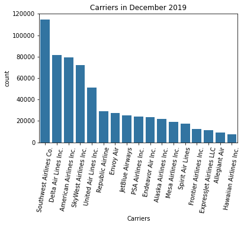

```python
#2019 flights - count the number of occurrences of each type of carrier
freq_2019 = df_flights_12_2019_new['CARRIER_DESCRIPTION'].value_counts()
gen_order_2019 = freq_2019.index
sb.countplot(data = df_flights_12_2019_new, x = 'CARRIER_DESCRIPTION', color = default_color, order=gen_order_2019)
plt.xticks(rotation=80)
plt.xlabel('Carriers')
plt.title('Carriers in December 2019')
```

### 1b. Frequency of flights by new in December 2020

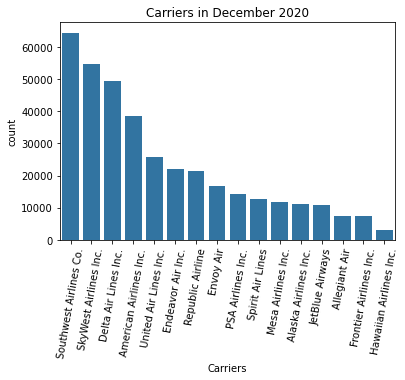

```python
#2020 flights
freq_2020 = df_flights_12_2020_new['CARRIER_DESCRIPTION'].value_counts()
gen_order_2020 = freq_2020.index
sb.countplot(data = df_flights_12_2020_new, x = 'CARRIER_DESCRIPTION', color = default_color, order=gen_order_2020)
plt.xticks(rotation=80)
plt.xlabel('Carriers')
plt.title('Carriers in December 2020')
```

**Observation:** One key observation from the plots is the major reduction in flights in December 2020 in comparison to 2019, indicating there were less travelers, an obvious effect of the Covid-19 pandemic. Also, there was one less carrier in 2020, most probably impacted by the reduction in travelers due to the Covid pandemic. The carrier with the most flights in both years was SouthWest Airlines, but the number of flights in 2020 was approximately half the amount in 2019. In 2020, other carriers did not maintain the same place as in 2019. SkyWest Airlines had the next highest frequency of flights in 2020, replacing Delta Airlines and pushing American Airlines from 3rd in 2019 to 4th in 2020.

**The following section investigates the distributions of arrival delays in December 2019 and in December 2020, separately. This involves looking at the arrival delays affecting each flight and the number of occurrences of each delay, then plotting a bar chart which shows the distribution.**

### 2a. Distribution of arrival delays in December 2019

```python
#convert data type of arrival delay column from float to integer
df_flights_12_2019_new.ARR_DELAY = df_flights_12_2019_new.ARR_DELAY.astype(int)
```

**The following counts the number of occurrences of each arrival delay incurred in December 2019**

```python
#Count the number of occurrences of each arrival delay
df_flights_12_2019_new.ARR_DELAY.value_counts()
```

```
 0       18682
-11      16630
-10      16616
-12      16602
-13      16426
         ...
 947         1
 683         1
-77          1
 1458        1
 511         1
Name: ARR_DELAY, Length: 1112, dtype: int64
```

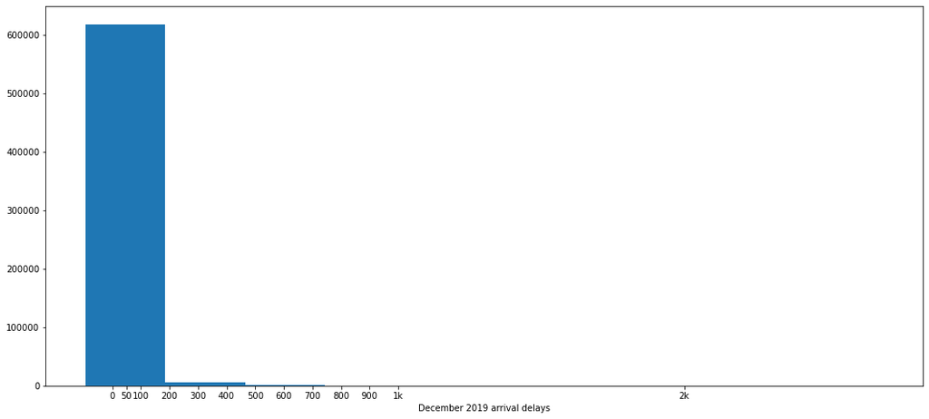

```python
# start with a standard-scaled plot
df_flights_12_2019_new.ARR_DELAY = df_flights_12_2019_new.ARR_DELAY.astype(int)
# binsize = 50
#Bin resizing
# bins = np.arange(0, df_flights_12_2019_new['ARR_DELAY'].max()+binsize, binsize)

plt.figure(figsize=[18, 8])
plt.hist(data = df_flights_12_2019_new, x = 'ARR_DELAY')
plt.xticks([0, 50, 100, 200, 300, 400, 500, 600, 700, 800, 900, 1e3, 2e3], [0, 50, 100, 200, 300, 400, 500, 600, 700, 800, 900, '1k', '2k'])

plt.xlabel('December 2019 arrival delays')
plt.show()
```

**The plot above shows the highest frequency of arrival delays were approximatly under 200 minutes long, but does not give a good visualization of the frequency of time periods less than 200. To get a better perspective of the length of time intervals smaller than 200 minutes I have taken a further step to replot with bins to see if we can get a better distribution of the data.**

```
[  5.           5.68705731   6.46852417   7.35737353   8.36836098
   9.51826969  10.82618905  12.31383151  14.00589309  15.93046334
  18.11949159  20.60931742  23.44127385  26.66237356  30.32608928
  34.49324154  39.23300828  44.62407329  50.75593243  57.7303793
  65.66319511  74.68607073  84.94879289  96.62173069 109.89866394
 125.         142.17643272 161.71310417 183.9343382  209.20902447
 237.95674234 270.65472614]
```

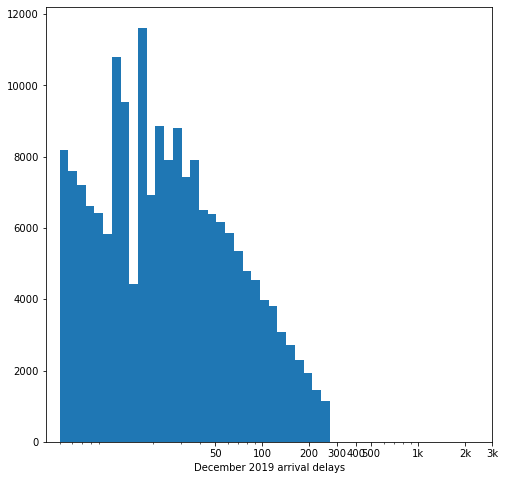

```python
log_binsize = 0.08
bins = 5 ** np.arange(1, np.log10(df_flights_12_2019_new['ARR_DELAY'].max())+log_binsize, log_binsize)
print(bins)
plt.figure(figsize=[8, 8])
plt.hist(data = df_flights_12_2019_new, x = 'ARR_DELAY', bins = bins)
plt.xscale('log')
plt.xticks([50, 100, 200, 300, 400, 500, 1e3, 2e3, 3e3], [50, 100, 200, 300, 400, 500, '1k', '2k', '3k'])
plt.xlabel('December 2019 arrival delays')
plt.show()
```

### 2b. Distribution of arrival delays in December 2020

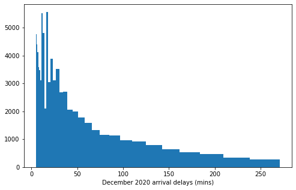

```python
# start with a standard-scaled plot
df_flights_12_2020_new.ARR_DELAY = df_flights_12_2020_new.ARR_DELAY.astype(int)
# binsize = 500
# bins = np.arange(0, df_flights_12_2020_new['ARR_DELAY'].max()+binsize, binsize)

plt.figure(figsize=[8, 5])
plt.hist(data = df_flights_12_2020_new, x = 'ARR_DELAY', bins = bins)
plt.xlabel('December 2020 arrival delays (mins)')
plt.show()
```

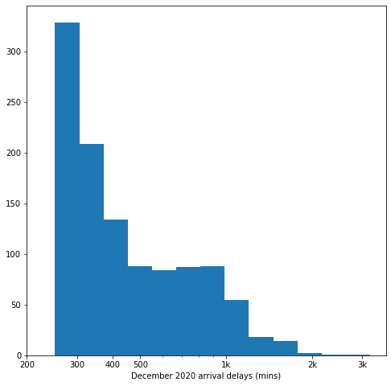

```python
log_binsize = 0.085
bins = 10 ** np.arange(2.4, np.log10(df_flights_12_2020_new['ARR_DELAY'].max())+log_binsize, log_binsize)

plt.figure(figsize=[8, 8])
plt.hist(data = df_flights_12_2020_new, x = 'ARR_DELAY', bins = bins)
plt.xscale('log')
plt.xticks([200, 300, 400, 500, 1e3, 2e3, 3e3], [200, 300, 400, 500, '1k', '2k', '3k'])
plt.xlabel('December 2020 arrival delays (mins)')
plt.show()
```

The arrival delays have a long tail distribution. This warrants further plotting - on a log-scale.

Based on the above plot, the highest frequency of delays across the US domestic routes in December 2020 was between 275 and 300 minutes, and decreased, as the plot skews off to the right, indicating long delays that were less frequent. Interestingly, there were a small number of times when delays exceeded 3000 mins or 50 hours, and this may reflect the changes that were implemented as a result of the impact the Covid pandemic had on the travel industry as a whole.

The plot for December 2020 is closely inline with 2019's in terms of the shape and the longest delay across the new is very much the same - 275 to 300 minutes, although there were less flights in 2020. Just like 2019, there was a very small number of times when the delays extended to 50 hours.

**Steps 3a and 3b investigate the distribution of the departure delays in December 2019 and 2020, respectively.**

### 3a. Distribution of departure delays in December 2019

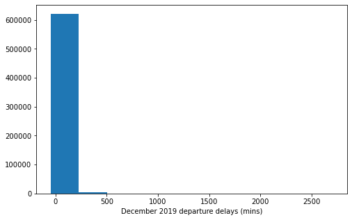

```python
# start with a standard-scaled plot
df_flights_12_2019_new.DEP_DELAY = df_flights_12_2019_new.DEP_DELAY.astype(int)
# binsize = 500
# bins = np.arange(0, df_flights_12_2019_new['DEP_DELAY'].max()+binsize, binsize)

plt.figure(figsize=[8, 5])
plt.hist(data = df_flights_12_2019_new, x = 'DEP_DELAY')
plt.xlabel('December 2019 departure delays (mins)')
plt.show()
```

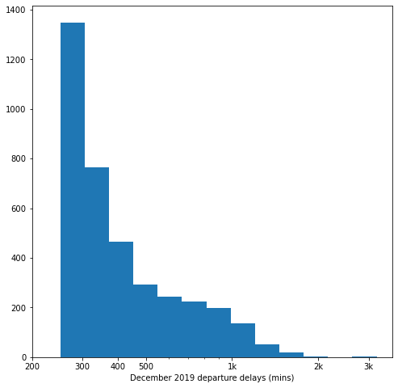

```python
log_binsize = 0.085
bins = 10 ** np.arange(2.4, np.log10(df_flights_12_2019_new['DEP_DELAY'].max())+log_binsize, log_binsize)

plt.figure(figsize=[8, 8])
plt.hist(data = df_flights_12_2019_new, x = 'DEP_DELAY', bins = bins)
plt.xscale('log')
plt.xticks([200, 300, 400, 500, 1e3, 2e3, 3e3], [200, 300, 400, 500, '1k', '2k', '3k'])
plt.xlabel('December 2019 departure delays (mins)')
plt.show()
```

Just like the plots for arrival delays, a second plot was done to get a better insight into the distribution of the data, by adding bins as well as log scale to above departure delays have a long tail distribution. So I applied logarthmic transform and bins to make the plot more interpretable.

Based on the above plot, the highest frequency of delays across the new along US domestic routes in December 2019 was between 275 and 300 minutes, and interestingly there were a small number of times when delays exceeded 3000 mins or 50 hours.

The plot for December 2020 is closely inline with 2019's in terms of the shape and the longest delay across the new is very much the same - 275 to 300 minutes, although there were less flights in 2020. Just like 2019, there was a very small number of times when the delays extended to 50 hours.

**The following investigates the distribution of the departure delays for December 2020**

### 3b. Distribution of departure delays in December 2020

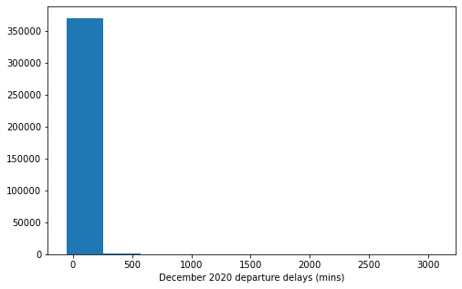

```python
# start with a standard-scaled plot
df_flights_12_2020_new.DEP_DELAY = df_flights_12_2020_new.DEP_DELAY.astype(int)
# binsize = 500
# bins = np.arange(-1000, df_flights_12_2020_new['DEP_DELAY'].max()+binsize, binsize)

plt.figure(figsize=[8, 5])
plt.hist(data = df_flights_12_2020_new, x = 'DEP_DELAY')
plt.xlabel('December 2020 departure delays (mins)')
plt.show()
```

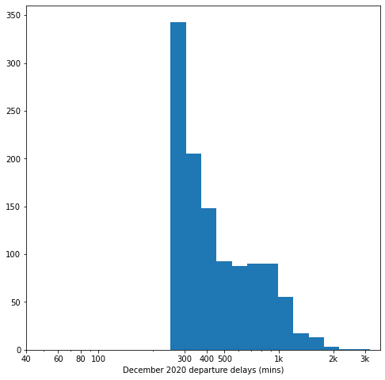

```python
#Define a binsize to add to the end of the upper limit returned by arange function below
log_binsize = 0.085
bins = 10 ** np.arange(2.4, np.log10(df_flights_12_2020_new['DEP_DELAY'].max())+log_binsize, log_binsize)
# bins = np.arange(2.4, np.log10(df_flights_12_2020_new['DEP_DELAY'].max())+log_binsize, log_binsize)
plt.figure(figsize=[8, 8])
plt.hist(data = df_flights_12_2020_new, x = 'DEP_DELAY', bins = bins)
plt.xscale('log')
plt.xticks([40, 60, 80, 100, 300, 400, 500, 1e3, 2e3, 3e3], [40, 60, 80, 100, 300, 400, 500, '1k', '2k', '3k'])
plt.xlabel('December 2020 departure delays (mins)')
plt.show()
```

The second departure delays plot skewes to the right with a tail.

The plot for December 2020 is closely inline with 2019's in terms of the shape and the longest delay across the new is very much the same - 275 to 300 minutes, although there were less flights in 2020. Just like 2019, there was a very small number of times when the delays extended to 50 hours.

**Steps 4a and 4b investigate the distribution of weather delays in December 2019 and 2020, respectively. It gives a visualization of the length of delays and their frequency.**

### 4a. Distribution of weather related delays affecting flights in December 2019

```python
#Check the frequency of delays to confirm weather there are zero delays
df_flights_12_2019_new['WEATHER_DELAY'].value_counts()
```

```
0.0       619643
2.0          196
7.0          195
1.0          192
3.0          186
           ...
529.0          1
614.0          1
292.0          1
1083.0         1
721.0          1
Name: WEATHER_DELAY, Length: 476, dtype: int64
```

**The counts above show that there are instances when weather delays were zero, which indicates no weather delay**

```python
df_flights_12_2019_new.info()
```

```
<class 'pandas.core.frame.DataFrame'>
Int64Index: 625763 entries, 0 to 625762
Data columns (total 87 columns):
 #   Column                   Non-Null Count   Dtype
---  ------                   --------------   -----
 0                            625763 non-null  int64
 1   QUARTER                  625763 non-null  int64
 2   MONTH                    625763 non-null  int64
 3   DAY_OF_MONTH             625763 non-null  int64
 4   DAY_OF_WEEK              625763 non-null  int64
 5   FL_DATE                  625763 non-null  object
 6   OP_UNIQUE_CARRIER        625763 non-null  object
 7   OP_CARRIER_AIRLINE_ID    625763 non-null  int64
 8   OP_CARRIER               625763 non-null  object
 9   TAIL_NUM                 625763 non-null  object
```

[output cut: 79 more lines]

#### Since there are many categories of weather delay minutes, only a portion of them will be sampled and plotted to show the distribution.

```
0      619643
2         196
7         195
1         192
3         186
        ...
498         1
499         1
502         1
514         1
508         1
Name: WEATHER_DELAY, Length: 476, dtype: int64
```

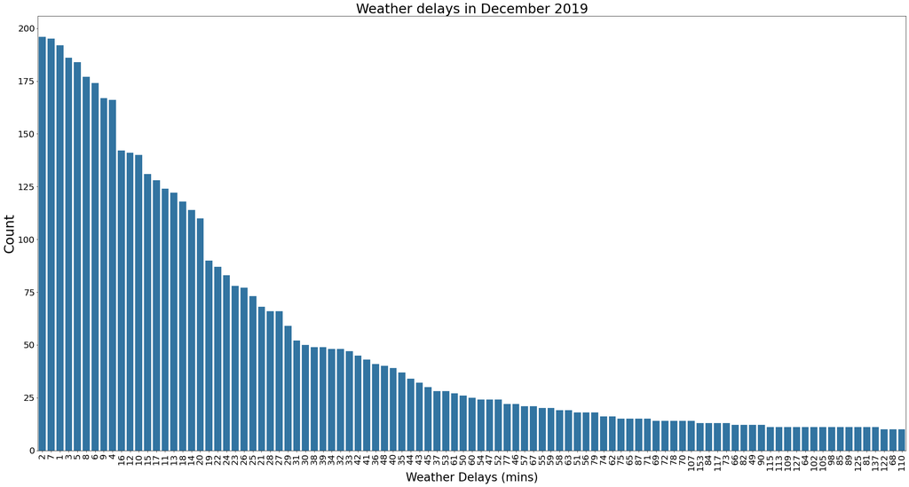

```python
#2019 flights
#Convert datatype of WEATHER_DELAY from float to integer
df_flights_12_2019_new.WEATHER_DELAY = df_flights_12_2019_new.WEATHER_DELAY.astype(int)
weather_2019 = df_flights_12_2019_new['WEATHER_DELAY'].value_counts().sort_values( ascending=False)
print(weather_2019)
#Skip the zero minute weather delay as this indicates no delay. Start at index 1
plt.figure(figsize=[35, 18])
plt.xlabel('WEATHER_DELAY', fontsize=26)
#Only use the data starting from index 1, because it's from here the weather delays are over zero.
#Since there is a vast range of data, we will use the first 100, to have better visualization - a less crowded plot
weather_order_2019 = weather_2019.index[1: 100]
sb.countplot(data = df_flights_12_2019_new, x = 'WEATHER_DELAY', color = default_color, order=weather_order_2019)
plt.xticks(rotation=90)
plt.tick_params(axis='both', which='major', labelsize=20)
plt.ylabel('Count', fontsize=30)
plt.xlabel('Weather Delays (mins)', fontsize=26)
plt.title('Weather delays in December 2019', fontsize=30)
```

#### The weather delay plot above is schewed to the right, with a long tail. It shows that the majority of weather related delays were reasonably small, with the most frequent delay being two minutes long, and the longer weather delays less frequent.

### 4b. Distribution of weather related delays affecting flights in December 2020

```
0       369081
15          51
5           48
21          48
7           45
         ...
248          1
1016         1
253          1
231          1
1023         1
Name: WEATHER_DELAY, Length: 366, dtype: int64
```

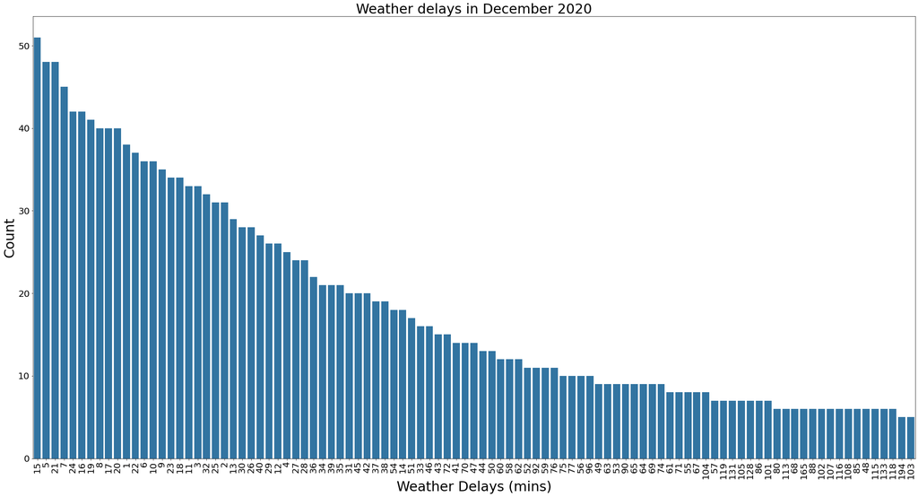

```python
#2020 flights
df_flights_12_2020_new.WEATHER_DELAY = df_flights_12_2020_new.WEATHER_DELAY.astype(int)
weather_2020 = df_flights_12_2020_new['WEATHER_DELAY'].value_counts().sort_values( ascending=False)
print(weather_2020)

plt.figure(figsize=[35, 18])
#Skip the zero minute weather delay as this indicates no delay. Start at index 1

weather_order_2020 = weather_2020.index[1: 100]
sb.countplot(data = df_flights_12_2020_new, x = 'WEATHER_DELAY', color = default_color, order=weather_order_2020)
plt.xticks(rotation=90)
plt.tick_params(axis='both', which='major', labelsize=20)
plt.xlabel('Weather Delays (mins)', fontsize=30)
plt.ylabel('Count', fontsize=30)
plt.title('Weather delays in December 2020', fontsize=30)
```

**Observation:** The plot above shows the highest frequency in weather delays were reasonably small (15 minutes). It gradually schews to the right, with many instances of longer delays which were less frequent. When compared to December 2019, the most frequent delays were larger in December 2020. Alternatively, there are quite a few of weather delays datapoints, which if combined will exceed the maximum frequency identified for the 15 minute delay datapoint. Delays over one hour were less frequent.

#### Plotting with log scale to get a better insight into the distribution

```python
weather_delay_sample = df_flights_12_2020_new[df_flights_12_2020_new.WEATHER_DELAY > 0].sort_values(by='WEATHER_DELAY', ascending=False)
```

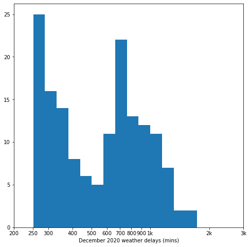

```python
log_binsize = 0.06
bins = 10 ** np.arange(2.4, np.log10(weather_delay_sample['WEATHER_DELAY'].max())+log_binsize, log_binsize)
plt.figure(figsize=[8, 8])
plt.hist(data = weather_delay_sample, x = 'WEATHER_DELAY', bins = bins)
plt.xscale('log')
plt.xticks([200, 250, 300, 400, 500, 600, 700, 800, 900, 1e3, 2e3, 3e3], [200, 250, 300, 400, 500, 600, 700, 800, 900,'1k', '2k', '3k'])
plt.xlabel('December 2020 weather delays (mins)')
plt.show()
```

**Observation for weather delays:** The above plot uses log scale to get a better insight into the distribution of the length of weather delays. It is more bimodal in shape, with a peak in frequency of delays between 250 minutes and 300 minutes and another peak ranging from just over 700 and 800 minutes, and the larger delays becoming less frequent. The extremely long delays can be considered outliers as there were not frequent - further investigation might be needed to see if there were due to extreme weather conditions.

**Steps 5a and 5b investigate the distribution of security delays in December 2019 and 2020, respectively. It gives a visualization of the length of delays and their frequency.**

### 5a. Distribution of security related delays affecting fights in December 2019

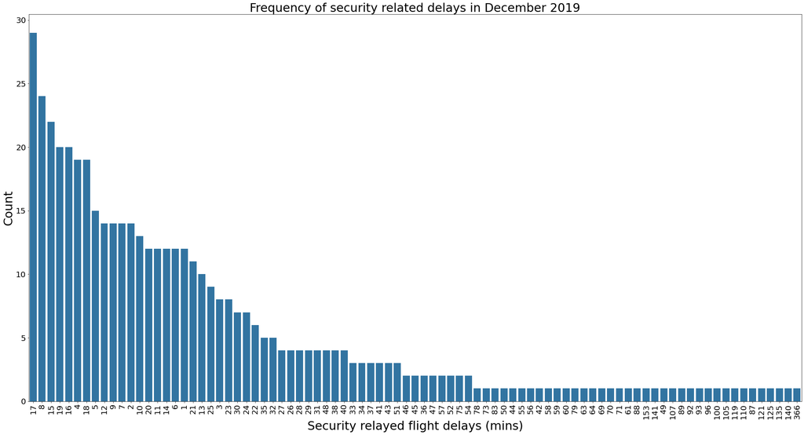

```python
#2020 flights
df_flights_12_2019_new.SECURITY_DELAY = df_flights_12_2019_new.SECURITY_DELAY.astype(int)
security_2019 = df_flights_12_2019_new['SECURITY_DELAY'].value_counts().sort_values( ascending=False)
#Skip the zero minute security delay as this indicates no delay. Start at index 1
plt.figure(figsize=[35, 18])
security_order_2019 = security_2019.index[1: 100]
sb.countplot(data = df_flights_12_2019_new, x = 'SECURITY_DELAY', color = default_color, order=security_order_2019)
plt.xticks(rotation=90)
plt.tick_params(axis='both', which='major', labelsize=20)
plt.xlabel('Security relayed flight delays (mins)', fontsize=30)
plt.ylabel('Count', fontsize=30)
plt.title('Frequency of security related delays in December 2019', fontsize=30)
```

#### Plotting with log scale to get a better insight into the distribution

```python
df_flights_12_2019_new['SECURITY_DELAY'].value_counts().sort_values(ascending=True)
```

```
366         1
141         1
135         1
125         1
121         1
        ...
19         20
15         22
8          24
17         29
0      625287
Name: SECURITY_DELAY, Length: 88, dtype: int64
```

```python
security_delay_sample_2019 = df_flights_12_2019_new[df_flights_12_2019_new.SECURITY_DELAY > 0].sort_values(by='SECURITY_DELAY', ascending=False)
```

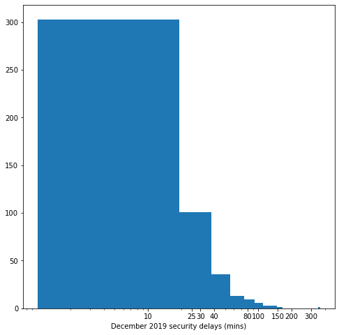

```python
log_binsize = 0.5
bins = 10 ** np.arange(2.4, np.log10(security_delay_sample_2019['SECURITY_DELAY'].max())+log_binsize, log_binsize)
plt.figure(figsize=[8, 8])
plt.hist(data = security_delay_sample_2019, x = 'SECURITY_DELAY', bins = 20)
plt.xscale('log')
plt.xticks([10, 25, 30, 40, 80, 100, 150, 200, 300], [10, 25, 30, 40, 80, 100, 150, 200, 300])
plt.xlabel('December 2019 security delays (mins)')
plt.show()
```

**Observation:** The above plot uses log scale to get a better insight into the distribution of the length of domestic delays due to security in December 2019. Again it skews to the right and ending with a tail. It showed that the majority of security related incidents resulted in most delays lasting from 1 to 20 minutes, and the larger delays becoming less frequent, with the highest delay time being around 100 to 150 minutes and one incident around 300 plus minutes, which might be considered an outlier because it only occurred once. Further investigation might be needed to see if there were due to extreme security conditions

### 5b. Distribution of security related delays affecting fights in December 2020

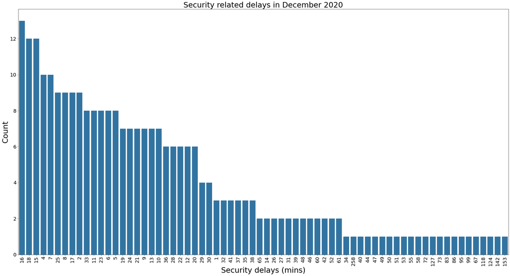

```python
#2020 flights
df_flights_12_2020_new.SECURITY_DELAY = df_flights_12_2020_new.SECURITY_DELAY.astype(int)
security_2020 = df_flights_12_2020_new['SECURITY_DELAY'].value_counts().sort_values( ascending=False)
#Skip the zero minute security delay as this indicates no delay. Start at index 1
plt.figure(figsize=[35, 18])
security_order_2020 = security_2020.index[1: 100]
sb.countplot(data = df_flights_12_2020_new, x = 'SECURITY_DELAY', color = default_color, order=security_order_2020)
plt.xticks(rotation=90)
plt.tick_params(axis='both', which='major', labelsize=20)
plt.xlabel('Security delays (mins)', fontsize=30)
plt.ylabel('Count', fontsize=30)
plt.title('Security related delays in December 2020', fontsize=30)
```

#### Plotting with log scale to get a better insight into the distribution

```python
security_delay_sample_2020 = df_flights_12_2020_new[df_flights_12_2020_new.SECURITY_DELAY > 0].sort_values(by='SECURITY_DELAY', ascending=False)
```

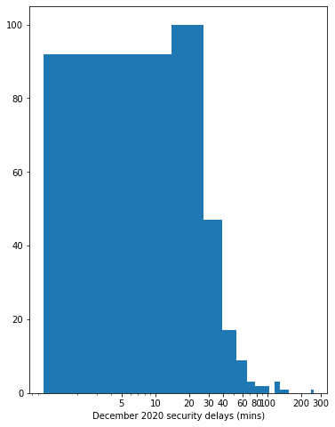

```python
log_binsize = 0.25
bins = 10 ** np.arange(2.4, np.log10(security_delay_sample_2020['SECURITY_DELAY'].max())+log_binsize, log_binsize)
plt.figure(figsize=[6, 8])
plt.hist(data = security_delay_sample_2020, x = 'SECURITY_DELAY', bins = 20)
plt.xscale('log')
# plt.xticks([200, 250, 300, 400, 500, 600, 700, 800, 900, 1e3, 2e3, 3e3], [200, 250, 300, 400, 500, 600, 700, 800, 900,'1k', '2k', '3k'])
plt.xticks([5, 10, 20, 30, 40, 60, 80, 100, 200, 300], [5, 10, 20, 30, 40, 60, 80, 100, 200, 300])
plt.xlabel('December 2020 security delays (mins)')
plt.show()
```

**Observation:** The above plot uses log scale to get a better insight into the distribution of the length of security delays. It skews to the right, with a peak (highest) number of security delays being between 15 and 20 minutes, with most of the security delays occuring between 1 and 15 minutes. There were instances of longer delays, but there were less frequent.

**Steps 6a and 6b investigate the distribution of carrier related delays in December 2019 and 2020, respectively. It gives a visualization of the length of delays and their frequency.**

### 6. Distribution of carrier related delays affecting flights in December 2019/2020

This explores the overall carrier delays in minutes and the frequency of the delays, and gives a visualization of the distribution of delays for December 2019 and 2020. The plot will order the carrier delays from the most frequent time to the least carrier delay time range.

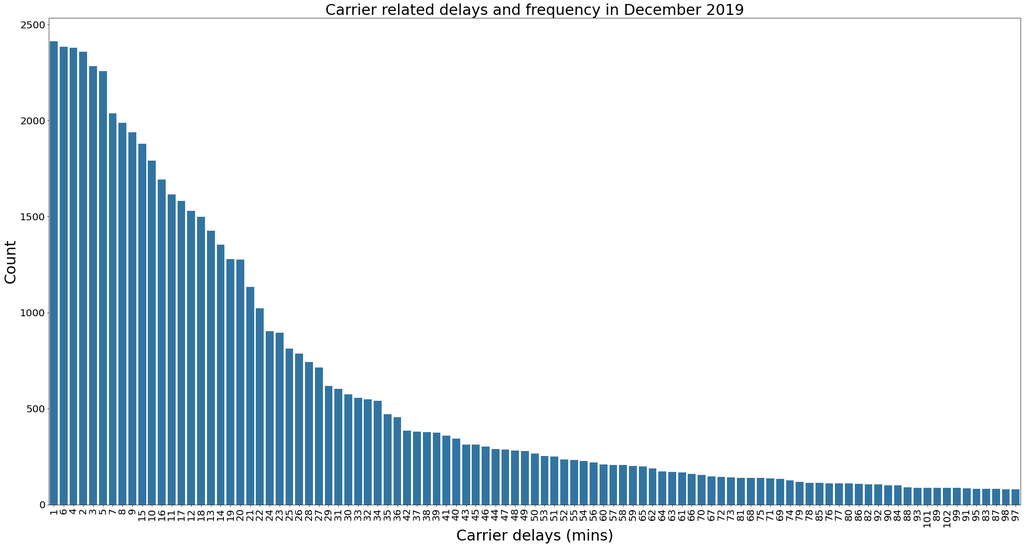

```python
#2020 flights
#Convert data type from float to integer
df_flights_12_2019_new.CARRIER_DELAY = df_flights_12_2019_new.CARRIER_DELAY.astype(int)
security_2019 = df_flights_12_2019_new['CARRIER_DELAY'].value_counts().sort_values( ascending=False)

plt.figure(figsize=[35, 18])
#Skip the zero minute carrier delay as this indicates no delay. Start at index 1
security_order_2019 = security_2019.index[1: 100]
sb.countplot(data = df_flights_12_2019_new, x = 'CARRIER_DELAY', color = default_color, order=security_order_2019)
plt.xticks(rotation=90)
plt.tick_params(axis='both', which='major', labelsize=20)
plt.xlabel('Carrier delays (mins)', fontsize=30)
plt.ylabel('Count', fontsize=30)
plt.title('Carrier related delays and frequency in December 2019', fontsize=30)
```

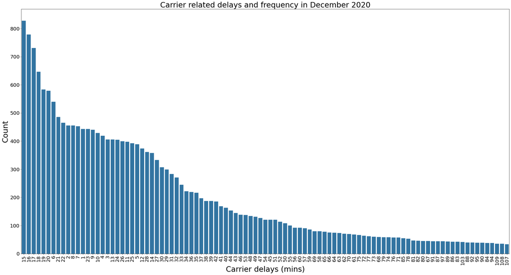

```python
#2020 flights
#Convert data type from float to integer
df_flights_12_2020_new.CARRIER_DELAY = df_flights_12_2020_new.CARRIER_DELAY.astype(int)
security_2020 = df_flights_12_2020_new['CARRIER_DELAY'].value_counts().sort_values( ascending=False)
plt.figure(figsize=[35, 18])
##Skip the zero minute carrier delay as this indicates no delay. Start at index 1
security_order_2020 = security_2020.index[1: 100]
sb.countplot(data = df_flights_12_2020_new, x = 'CARRIER_DELAY', color = default_color, order=security_order_2020)
plt.xticks(rotation=90)
plt.tick_params(axis='both', which='major', labelsize=20)
plt.xlabel('Carrier delays (mins)', fontsize=30)
plt.ylabel('Count', fontsize=30)
plt.title('Carrier related delays and frequency in December 2020', fontsize=30)
```

**Observation:** Both plots skew to the right and ends with a long tail like shape. It's quite interesting to note that the most frequent carrier related delay length of time in December 2019 was 1 minute, and 15 minutes in 2020. Although there is a vast gap between the two years, it isn't that surprising, because of the changes to the travel industry in the heart of the pandemic. And even with the effect of the pandemic, for the most part 2020 overall didn't look that bad, when compared to 2019, because the less frequent delays, in both years, were around 30 to 60 minutes and fewer that were longer.

#### Plotting with log scale to see if I can get a better insight into the distribution

```python
security_delay_sample_2020 = df_flights_12_2020_new[df_flights_12_2020_new.CARRIER_DELAY > 0].sort_values(by='CARRIER_DELAY', ascending=False)
```

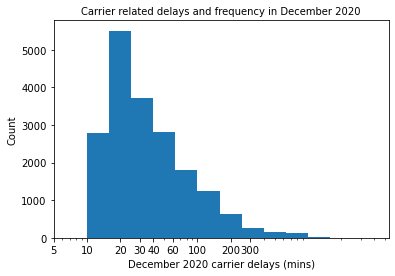

```python
log_binsize = 0.2
bins = 10 ** np.arange(1, np.log10(security_delay_sample_2020['CARRIER_DELAY'].max())+log_binsize, log_binsize)
plt.figure(figsize=[6, 4])
plt.hist(data = security_delay_sample_2020, x = 'CARRIER_DELAY', bins = bins)
plt.xscale('log')
plt.xticks([5, 10, 20, 30, 40, 60, 100, 200, 300], [5, 10, 20, 30, 40, 60, 100, 200, 300])
plt.xlabel('December 2020 carrier delays (mins)')
plt.ylabel('Count', fontsize=10)
plt.title('Carrier related delays and frequency in December 2020', fontsize=10)
plt.show()
```

**Observation:** The above plot uses log scale to get a better insight into the distribution of the length of carrier delays. It skews to the right, the same as the ones above it, but clumps a big range of carrier delays and makes it hard to draw any accurate conclusions from this range.

**Sections 7a and 7b explore the overall late aircraft delays in minutes and the frequency of these delays, and gives a visualization of the distribution of delays for December 2019 and 2020. The plot will order the delays from the most frequent time to the least frequency.**

### 7a. Distribution of late aircraft delays in December 2019

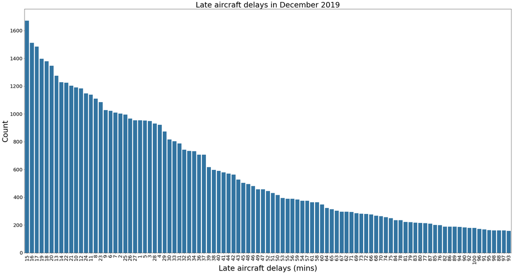

```python
#2019 flights
df_flights_12_2019_new.LATE_AIRCRAFT_DELAY = df_flights_12_2019_new.LATE_AIRCRAFT_DELAY.astype(int)
aircraft_delay_2019 = df_flights_12_2019_new['LATE_AIRCRAFT_DELAY'].value_counts().sort_values( ascending=False)
plt.figure(figsize=[35, 18])
#Skip the zero minute late_aircraft delay as this indicates no delay. Start at index 1
aircraft_order_2019 = aircraft_delay_2019.index[1: 100]
sb.countplot(data = df_flights_12_2019_new, x = 'LATE_AIRCRAFT_DELAY', color = default_color, order=aircraft_order_2019)
plt.xticks(rotation=90)
plt.tick_params(axis='both', which='major', labelsize=20)
plt.xlabel('Late aircraft delays (mins)', fontsize=30)
plt.ylabel('Count', fontsize=30)
plt.title('Late aircraft delays in December 2019', fontsize=30)
```

#### Plotting with log scale to get a better insight into the distribution

```python
lateaircraft_delay_sample_2019 = df_flights_12_2019_new[df_flights_12_2019_new.LATE_AIRCRAFT_DELAY > 0].sort_values(by='SECURITY_DELAY', ascending=False)
```

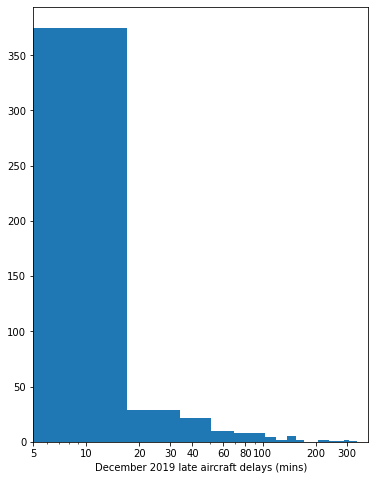

```python
log_binsize = 0.25
bins = 10 ** np.arange(2.4, np.log10(lateaircraft_delay_sample_2019['LATE_AIRCRAFT_DELAY'].max())+log_binsize, log_binsize)
plt.figure(figsize=[6, 8])
plt.hist(data = security_delay_sample_2019, x = 'LATE_AIRCRAFT_DELAY', bins = 20)
plt.xscale('log')
plt.xticks([5, 10, 20, 30, 40, 60, 80, 100, 200, 300], [5, 10, 20, 30, 40, 60, 80, 100, 200, 300])
plt.xlabel('December 2019 late aircraft delays (mins)')
plt.show()
```

**The above plot uses log scale to get a better insight into the distribution of the length ol late aircraft delays. It skews to the right, and gives a better insight and reveals what I would interpret as outliers - starting around the 200 and 300 minute range.**

### 7b. Distribution of late aircraft delays affecting flights in December 2020

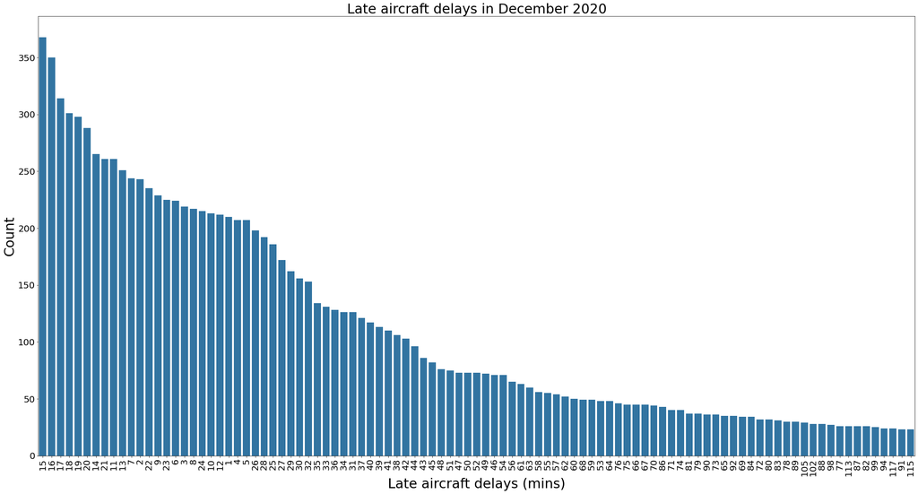

```python
#2020 flights - because of the volume of data, only a sample of the data is captured for better visualization
df_flights_12_2020_new.LATE_AIRCRAFT_DELAY = df_flights_12_2020_new.LATE_AIRCRAFT_DELAY.astype(int)
aircraft_delay_2020 = df_flights_12_2020_new['LATE_AIRCRAFT_DELAY'].value_counts().sort_values( ascending=False)

#Skip the zero minute late_aircraft delay as this indicates no delay. Start at index 1
plt.figure(figsize=[35, 18])
aircraft_order_2020 = aircraft_delay_2020.index[1:100]
sb.countplot(data = df_flights_12_2020_new, x = 'LATE_AIRCRAFT_DELAY', color = default_color, order=aircraft_order_2020)
plt.xticks(rotation=90)
plt.tick_params(axis='both', which='major', labelsize=20)
plt.xlabel('Late aircraft delays (mins)', fontsize=30)
plt.ylabel('Count', fontsize=30)
plt.title('Late aircraft delays in December 2020', fontsize=30)
```

**Observation:**The late aircraft delays plot for December 2020 looks very similar to 2019 - has a step like look which skews right and forms a tail. The highest frequency of late aircraft delays is the same as 2019, 15 minutes. I notice that there were some instances of longer delays, in 2020, although less frequent, but a bit more than 2019.

**Section 8 explores the delays caused by National Air System (NAS) and the frequency of these delays, and gives a visualization of the distribution for December 2019 and 2020. The plot will order the delays from the most frequent time to the least frequency.**

### 8. Distribution of National Air System Delays affecting flights in December 2019 and 2020

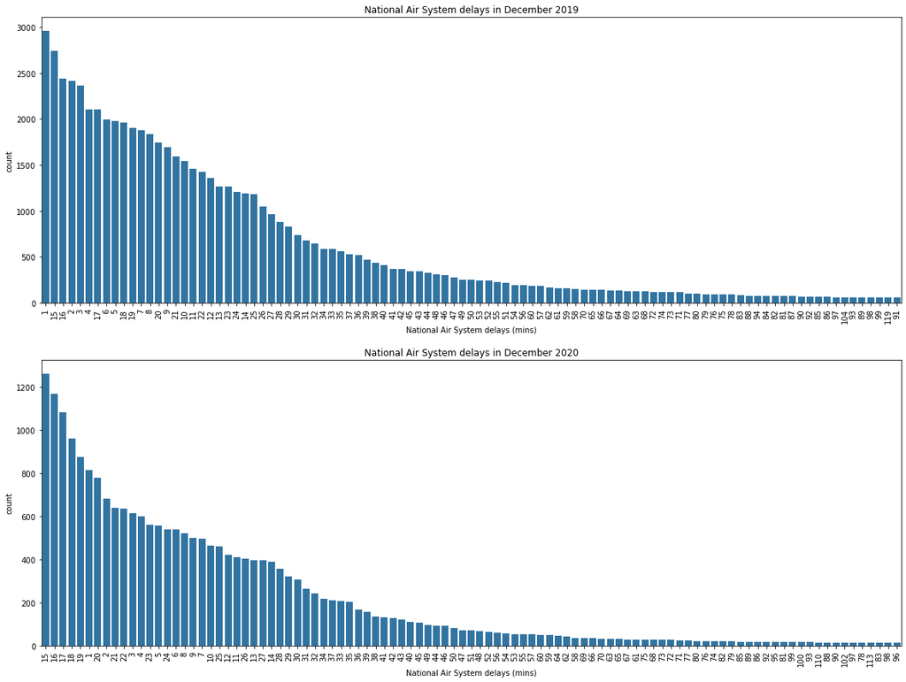

```python
#-----------------Plot types of cancellations in December 2019----------------
f,ax=plt.subplots(nrows=2,figsize=(20,15))
#Convert data type to integer
df_flights_12_2019_new.NAS_DELAY = df_flights_12_2019_new.NAS_DELAY.astype(int)

freq_2019_nas = df_flights_12_2019_new['NAS_DELAY'].value_counts().sort_values( ascending=False)
nas_order_2019 = freq_2019_nas.index[1:100]
ax[0].tick_params(axis="x", rotation=90)
sb.countplot(data = df_flights_12_2019_new, x = 'NAS_DELAY', color = default_color, order=nas_order_2019, ax=ax[0])
ax[0].set_xlabel('National Air System delays (mins)')
ax[0].set_title('National Air System delays in December 2019')

#------------Plot types of cancellations in December 2020----------------

df_flights_12_2020_new.NAS_DELAY = df_flights_12_2020_new.NAS_DELAY.astype(int)
freq_2020_nas = df_flights_12_2020_new['NAS_DELAY'].value_counts().sort_values( ascending=False)
nas_order_2020 = freq_2020_nas.index[1:100]
ax[1].tick_params(axis="x", rotation=90)
sb.countplot(data = df_flights_12_2020_new, x = 'NAS_DELAY', color = default_color, order=nas_order_2020, ax=ax[1])
ax[1].set_xlabel('National Air System delays (mins)')
ax[1].set_title('National Air System delays in December 2020')

plt.show()
```

**The below continues assessing the NAS delays by taking another look using matplotlib's hist() function.**

```python
#Only select data where NAS DELAY is greater than zero, since zero means no delays
nas_delay_sample_2019 = df_flights_12_2019_new[df_flights_12_2019_new.NAS_DELAY > 0].sort_values(by='NAS_DELAY', ascending=False)
```

```python
#Only select data where NAS DELAY is greater than zero, since zero means no delays
nas_delay_sample_2020 = df_flights_12_2020_new[df_flights_12_2020_new.NAS_DELAY > 0].sort_values(by='NAS_DELAY', ascending=False)
```

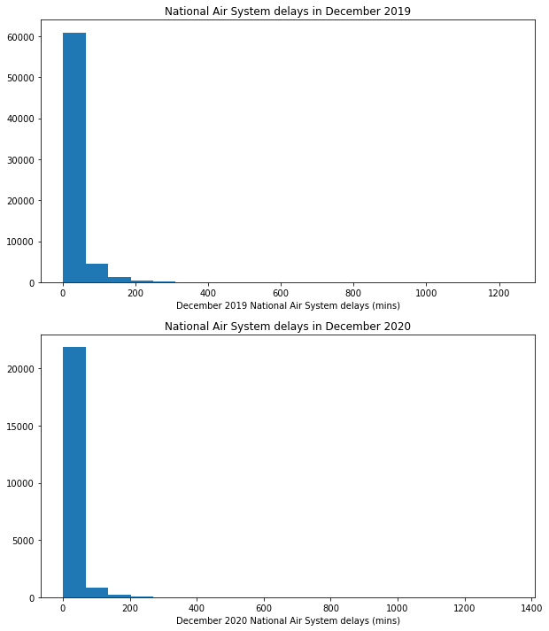

```python
# log_binsize = 1
# bins = 1 ** np.arange(2.4, np.log10(nas_delay_sample_2019['NAS_DELAY'].max())+log_binsize, log_binsize)

fig, ax = plt.subplots(nrows=2, figsize = [10,12])
#------- plot 2019 ------------
ax[0].hist(data = nas_delay_sample_2019, x = 'NAS_DELAY', bins = 20)
# plt.xscale('log')
# plt.xticks([5, 10, 20, 30, 40, 60, 80, 100, 200, 300], [5, 10, 20, 30, 40, 60, 80, 100, 200, 300])
ax[0].set_xlabel('December 2019 National Air System delays (mins)')
ax[0].set_title('National Air System delays in December 2019')

#------ plot 2020---------------
ax[1].hist(data = nas_delay_sample_2020, x = 'NAS_DELAY', bins = 20)
# plt.xscale('log')
# plt.xticks([5, 10, 20, 30, 40, 60, 80, 100, 200, 300], [5, 10, 20, 30, 40, 60, 80, 100, 200, 300])
ax[1].set_xlabel('December 2020 National Air System delays (mins)')
ax[1].set_title('National Air System delays in December 2020')

# plt.show()
```

**Section 9 explores the different types of cancellations presented in the dataset, and plots them side by side to compare the frequency of occurrences in December 2019 and 2020.**

### 9. Reasons for flights cancellations

```python
#Confirm that there are cancellation codes in 2019
df_flights_12_2019_new['CANCELLATION_CODE'].value_counts()
```

```
0    619970
B      3155
A      1603
C      1035
Name: CANCELLATION_CODE, dtype: int64
```

```python
#Confirm that there are cancellation codes in 2020
df_flights_12_2020_new['CANCELLATION_CODE'].value_counts()
```

```
0    367507
B      2445
A       717
D       404
C       284
Name: CANCELLATION_CODE, dtype: int64
```

**Use Seaborn to create bar plots side by side**

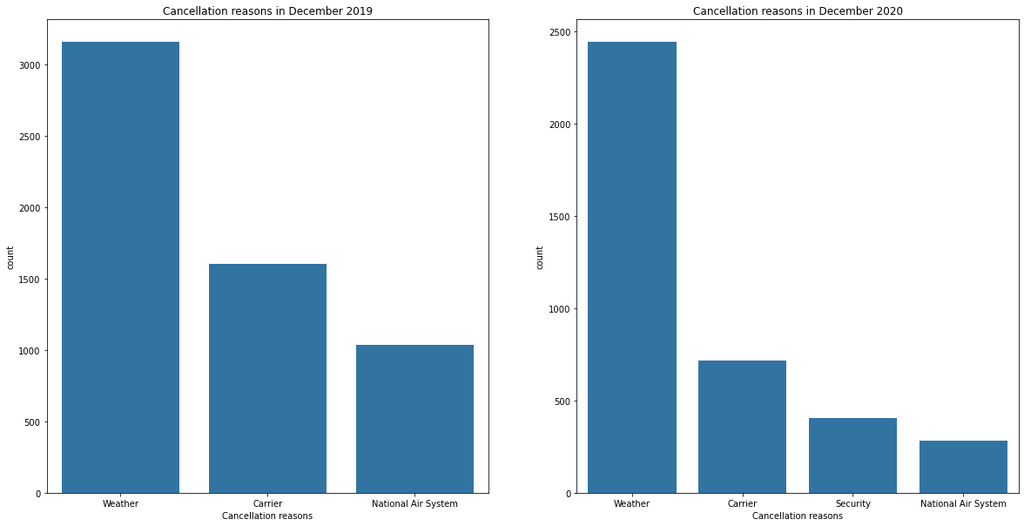

```python
#Plot types of cancellations in December 2019
f,ax=plt.subplots(1,2,figsize=(20,10))

#Get the cancellation descriptions for December 2019
freq_2019_cancelled = df_flights_12_2019_new['CANCELLED_DESCRIPTION'].value_counts()
cancelled_order_2019 = freq_2019_cancelled.index
sb.countplot(data = df_flights_12_2019_new, x = 'CANCELLED_DESCRIPTION', color = default_color, order=cancelled_order_2019, ax=ax[0])
ax[0].set_xlabel('Cancellation reasons')
ax[0].set_title('Cancellation reasons in December 2019')

#Plot types of cancellations in December 2020
#Get the cancellation descriptions for December 2020
freq_2020_cancelled = df_flights_12_2020_new['CANCELLED_DESCRIPTION'].value_counts()
cancelled_order_2020 = freq_2020_cancelled.index
sb.countplot(data = df_flights_12_2020_new, x = 'CANCELLED_DESCRIPTION', color = default_color, order=cancelled_order_2020, ax=ax[1])
ax[1].set_xlabel('Cancellation reasons')
ax[1].set_title('Cancellation reasons in December 2020')

plt.show()
```

**Section 10 explores the different cities from which flights orginated in December 2019 and 2020, to see the frequency of flights, and plots them to visualize the frequency of occurrences.**

### 10. Frequency of flights from cities of origin

```python
#Get the counts of occurrences of each city
df_flights_12_2019_new['ORIGIN_CITY_NAME'].value_counts()
```

```
Chicago, IL              34304
Atlanta, GA              32296
Dallas/Fort Worth, TX    25516
New York, NY             24155
Denver, CO               21333
                         ...
Ogden, UT                    9
Owensboro, KY                9
Adak Island, AK              8
Greenville, NC               2
Cody, WY                     1
Name: ORIGIN_CITY_NAME, Length: 343, dtype: int64
```

```python
freq_2019_cancelled.index
```

```
Index(['Weather', 'Carrier', 'National Air System'], dtype='object')
```

**Create a new column in 2019 and 2020 dataframes to hold the concatenation of airport code and ORIGIN_CITY_NAME - this is done because some cities have multiple airports, e.g. LGA New York, JFK New York**

```python
#Create new column in 2019
df_flights_12_2019_new['ORIGIN_CITY'] =  "(" + df_flights_12_2019_new['ORIGIN'] + ") " + df_flights_12_2019_new['ORIGIN_CITY_NAME']
```

```python
#Create new column in 2020
df_flights_12_2020_new['ORIGIN_CITY'] = "(" + df_flights_12_2020_new['ORIGIN'] + ") " + df_flights_12_2020_new['ORIGIN_CITY_NAME']
```

```python
# origin_2019
df_flights_12_2019_new['ORIGIN_CITY'].value_counts()
```

```
(ATL) Atlanta, GA              32296
(ORD) Chicago, IL              27447
(DFW) Dallas/Fort Worth, TX    25516
(DEN) Denver, CO               21333
(CLT) Charlotte, NC            19748
                               ...
(OGD) Ogden, UT                    9
(OWB) Owensboro, KY                9
(ADK) Adak Island, AK              8
(PGV) Greenville, NC               2
(COD) Cody, WY                     1
Name: ORIGIN_CITY, Length: 350, dtype: int64
```

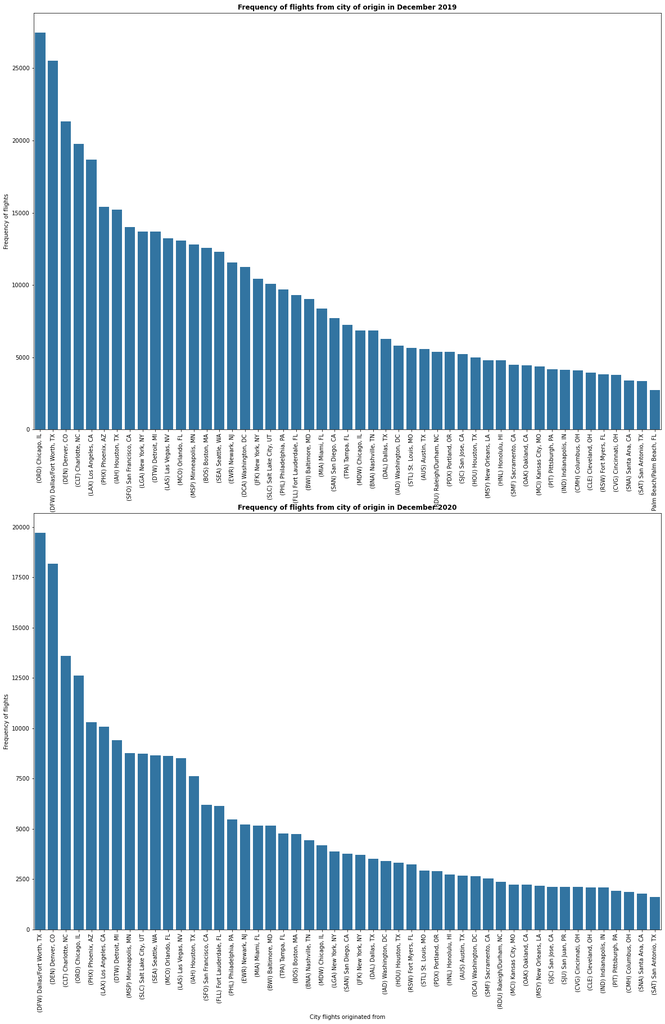

```python
#Plot city of flight origin in December 2019
f,ax=plt.subplots(nrows=2,figsize=(20,30))
#Create a variable to store the newly concatenated values, ordered by the largest occurrences to the smallest
origin_2019 = df_flights_12_2019_new['ORIGIN_CITY'].value_counts()
#use the first 50 values returned
city_origin_2019 = origin_2019.index[1:50]
sb.countplot(data = df_flights_12_2019_new, x = 'ORIGIN_CITY', color = default_color, order=city_origin_2019, ax=ax[0])
ax[0].set_xlabel('City flights originated from')
ax[0].set_ylabel('Frequency of flights')
ax[0].set_title('Frequency of flights from city of origin in December 2019', fontweight='bold')
ax[0].tick_params(axis="x", rotation=90)

#Plot city of flight origin in December 2020
origin_2020 = df_flights_12_2020_new['ORIGIN_CITY'].value_counts()
#use the first 50 values returned
city_origin_2020 = origin_2020.index[1:50]
sb.countplot(data = df_flights_12_2020_new, x = 'ORIGIN_CITY', color = default_color, order=city_origin_2020, ax=ax[1])
ax[1].set_xlabel('City flights originated from')
ax[1].set_ylabel('Frequency of flights')
ax[1].set_title('Frequency of flights from city of origin in December 2020',  fontweight='bold')
ax[1].tick_params(axis="x", rotation=90)
plt.show()
```

**Section 11 explores the frequency of flights from destination airports in December 2019 and 2020, to see the frequency of flights, and provide plots that show the airports and frequency of flights.**

### 11. Frequency of flights at destination airports

```python
df_flights_12_2019_new['DEST_CITY_NAME'].value_counts()
```

```
Chicago, IL              34252
Atlanta, GA              32314
Dallas/Fort Worth, TX    25505
New York, NY             24158
Denver, CO               21332
                         ...
Owensboro, KY                9
Ogden, UT                    9
Adak Island, AK              8
Greenville, NC               2
Cody, WY                     2
Name: DEST_CITY_NAME, Length: 343, dtype: int64
```

**Create a new column in 2019 and 2020 dataframes to hold the concatenation of destination airport code and DEST_CITY_NAME - this is done because some cities have multiple airports, e.g. LGA New York, JFK New York**

```python
df_flights_12_2019_new['DEST_CITY'] =  "(" + df_flights_12_2019_new['DEST'] + ") " + df_flights_12_2019_new['DEST_CITY_NAME']
```

```python
df_flights_12_2020_new['DEST_CITY'] = "(" + df_flights_12_2020_new['DEST'] + ") " + df_flights_12_2020_new['DEST_CITY_NAME']
```

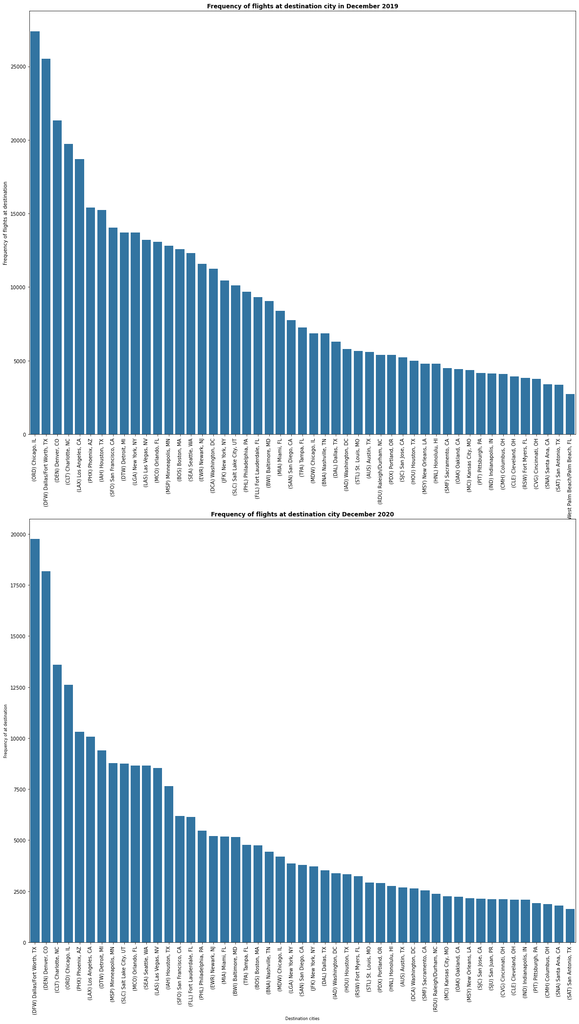

```python
#Plot city of flight origin in December 2019
f,ax=plt.subplots(nrows=2,figsize=(20,35))
#Create a variable to store the newly concatenated values, ordered by the largest occurrences to the smallest
dest_2019 = df_flights_12_2019_new['DEST_CITY'].value_counts()
city_dest_2019 = dest_2019.index[1:50]
sb.countplot(data = df_flights_12_2019_new, x = 'DEST_CITY', color = default_color, order=city_dest_2019, ax=ax[0])
ax[0].set_xlabel('Destination cities')
ax[0].set_ylabel('Frequency of flights at destination')
ax[0].set_title('Frequency of flights at destination city in December 2019',  fontweight='bold')
ax[0].tick_params(axis="x", rotation=90)

#Plot city of flight origin in December 2020
#Create a variable to store the newly concatenated values, ordered by the largest occurrences to the smallest
dest_2020 = df_flights_12_2020_new['DEST_CITY'].value_counts()
city_dest_2020 = dest_2020.index[1:50]
sb.countplot(data = df_flights_12_2020_new, x = 'DEST_CITY', color = default_color, order=city_dest_2020, ax=ax[1])
ax[1].set_xlabel('Destination cities', fontsize = 8)
ax[1].set_ylabel('Frequency of at destination', fontsize = 8)
ax[1].set_title('Frequency of flights at destination city December 2020',  fontweight='bold')
ax[1].tick_params(axis="x", rotation=90)
plt.show()
```

**Section 12 explores the distribution of departure time blocks in December 2019 and 2020, to see which time slots are the busiest in terms and slowest in terms of flights. Plots were created to give a better visualization.**

### 12. Distribution of blocks of departure times

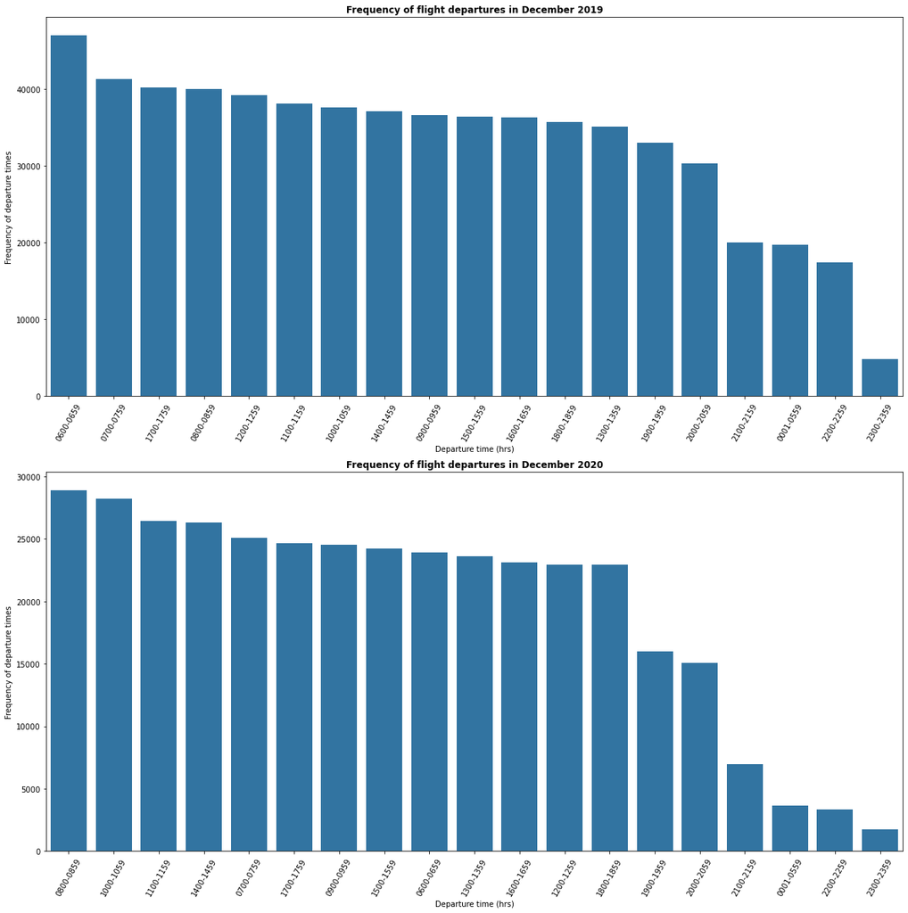

```python
#Plot departure time blocks in December 2019
f,ax=plt.subplots(nrows=2,figsize=(20,20))
#Create a variable to store the departure time blocks, ordered by the largest occurrences to the smallest
dest_2019 = df_flights_12_2019_new['DEP_TIME_BLK'].value_counts()
city_dest_2019 = dest_2019.index
sb.countplot(data = df_flights_12_2019_new, x = 'DEP_TIME_BLK', color = default_color, order=city_dest_2019, ax=ax[0])
ax[0].set_xlabel('Departure time (hrs)')
ax[0].set_ylabel('Frequency of departure times')
ax[0].set_title('Frequency of flight departures in December 2019', fontweight = 'bold')
ax[0].tick_params(axis="x", rotation=60)

#Plot departure time blocks in December 2020
#Create a variable to store the departure time blocks, ordered by the largest occurrences to the smallest
dest_2020 = df_flights_12_2020_new['DEP_TIME_BLK'].value_counts()
city_dest_2020 = dest_2020.index
sb.countplot(data = df_flights_12_2020_new, x = 'DEP_TIME_BLK', color = default_color, order=city_dest_2020, ax=ax[1])
ax[1].set_xlabel('Departure time (hrs)')
ax[1].set_ylabel('Frequency of departure times')
ax[1].set_title('Frequency of flight departures in December 2020', fontweight = 'bold')
ax[1].tick_params(axis="x", rotation=60)
plt.show()
```

**Observation:** The plots showed that the time slots with the largest number of departure flights was between 0600 and 0659 hours in December 2019, whereas in December 2020, the most frequent flights were between 0800 and 0859 hours. The timeslot with the least departure flights was between 2300 and 2359 hours in both December 2019 and December 2020. The next busiest time for departure was between 0700 and 0759 with a gradual decline various time of the day - between 1700-1759, 0800-0859 e.t.c. In December 2020, flights were 2nd in frequency between 1000 and 1059 hours, and the frequency dropped gradually between 1100 and 1159, then aroun 2000 hours. Also as expected the frequency of flights were overall less in 2020 than 2019, because of the impact to travel during the pandemic.

**Section 13 explores the distribution of flight arrivals time blocks in December 2019 and 2020, to see which time slots have the busiest and slowest in terms of the frequency of flights. Plots were created to give a better visualization.**

### 13. Distribution of flight arrivals time slots

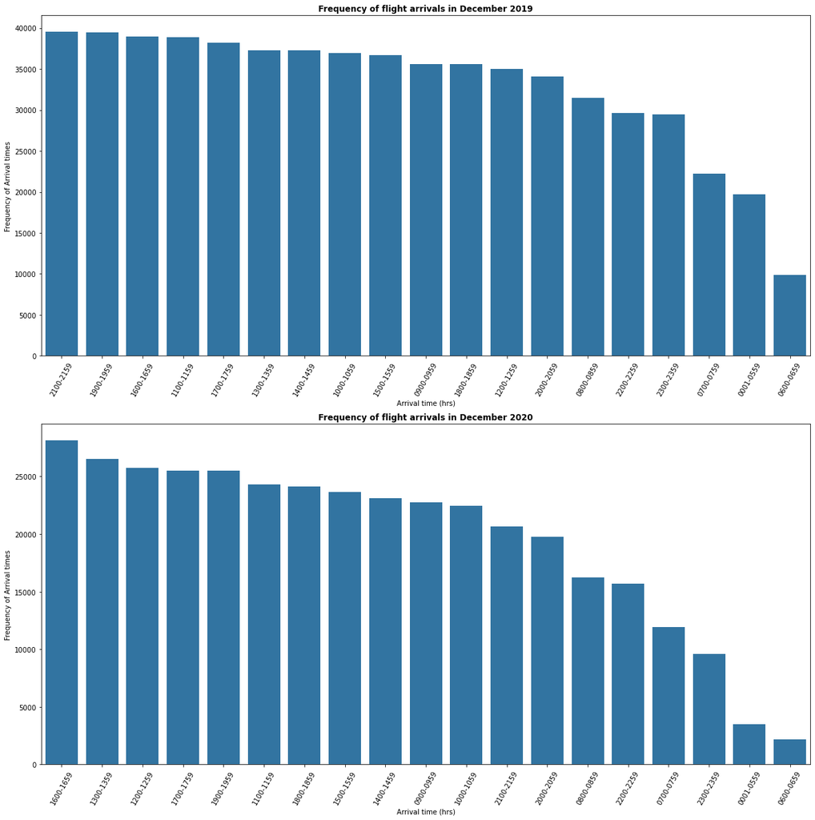

```python
#Plot arrival time blocks in December 2019
f,ax=plt.subplots(nrows=2,figsize=(20,20))
#Create a variable to store the arrival time blocks, ordered by the largest occurrences to the smallest
arr_2019 = df_flights_12_2019_new['ARR_TIME_BLK'].value_counts()
#get the order of the arrival times
city_arr_2019 = arr_2019.index
sb.countplot(data = df_flights_12_2019_new, x = 'ARR_TIME_BLK', color = default_color, order=city_arr_2019, ax=ax[0])
ax[0].set_xlabel('Arrival time (hrs)')
ax[0].set_ylabel('Frequency of Arrival times')
ax[0].set_title('Frequency of flight arrivals in December 2019', fontweight='bold')
ax[0].tick_params(axis="x", rotation=60)

#Plot arrival time blocks in December 2020
#Create a variable to store the arrival time blocks, ordered by the largest occurrences to the smallest
arr_2020 = df_flights_12_2020_new['ARR_TIME_BLK'].value_counts()
#get the order of the arrival times
city_arr_2020 = arr_2020.index
sb.countplot(data = df_flights_12_2020_new, x = 'ARR_TIME_BLK', color = default_color, order=city_arr_2020, ax=ax[1])
ax[1].set_xlabel('Arrival time (hrs)')
ax[1].set_ylabel('Frequency of Arrival times')
ax[1].set_title('Frequency of flight arrivals in December 2020', fontweight='bold')
ax[1].tick_params(axis="x", rotation=60)
plt.show()
```

**Observation:** The plots above show that the time slots with the largest number of flight arrivals were between 2100 and 2159 hours and 1900 to 1959, closely behind, in December 2019, whereas in December 2020, the most frequent flights arrived between 1600 and 1659 hours. The timeslot with the least arrivals was between 0600 and 0659 hours in both December 2019 and December 2020. The next busiest time slots for arrivals were from 1600 to 0759 and 1100 to 1159 hours in December 2019, and 1300 to 1359, 1200 to 1259, 1700 to 1759 and 1900 to 1959 in December 2020. Also, as expected, overall, the frequency of flight arrivals was less in 2020 than in 2019, due to the impact to travelling during the pandemic. The frequency of flight arrivals graually declined during various time slots as shown in both plots.

**Section 14 explores the distribution of flights each week day in December 2019 and 2020, to see which days of the week have the most and least frequency of flights. Plots were created to give a better visualization.**

### 14. Distribution of flights each day of the week

This explores the number of flights each day of the week in December in 2019 and 2020

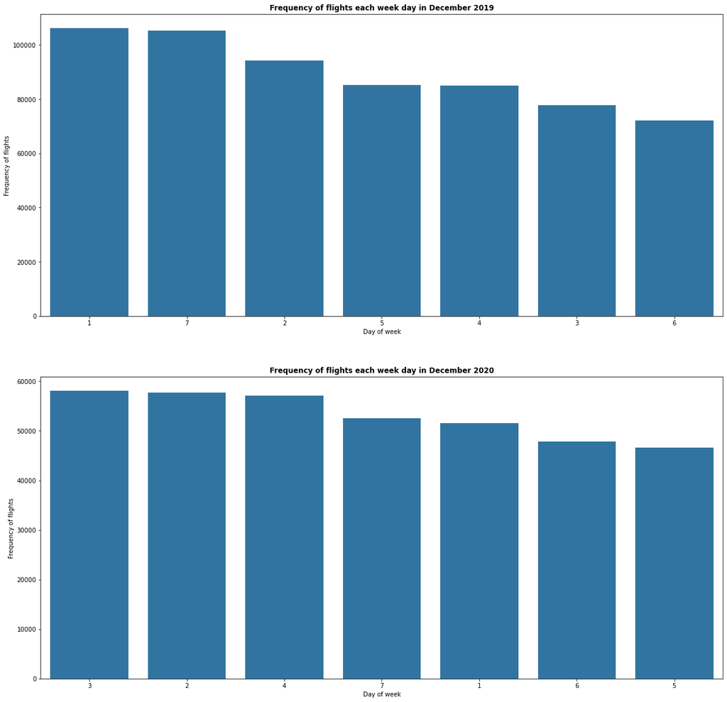

```python
#Plot December 2019
f,ax=plt.subplots(nrows=2,figsize=(20,20))
#Create a variable to store the frequencies of the day of the week, ordered by the largest occurrences to the smallest
weeks_2019 = df_flights_12_2019_new['DAY_OF_WEEK'].value_counts()
city_weeks_2019 = weeks_2019.index
sb.countplot(data = df_flights_12_2019_new, x = 'DAY_OF_WEEK', color = default_color, order=city_weeks_2019, ax=ax[0])
ax[0].set_xlabel('Day of week')
ax[0].set_ylabel('Frequency of flights')
ax[0].set_title('Frequency of flights each week day in December 2019', fontweight='bold')
ax[0].tick_params(axis="x", rotation=0)

#Plot December 2020
#Create a variable to store the frequencies of the day of the week, ordered by the largest occurrences to the smallest
weeks_2020 = df_flights_12_2020_new['DAY_OF_WEEK'].value_counts()
city_weeks_2020 =weeks_2020.index
sb.countplot(data = df_flights_12_2020_new, x = 'DAY_OF_WEEK', color = default_color, order=city_weeks_2020, ax=ax[1])
ax[1].set_xlabel('Day of week')
ax[1].set_ylabel('Frequency of flights')
ax[1].set_title('Frequency of flights each week day in December 2020', fontweight='bold')
ax[1].tick_params(axis="x", rotation=0)
plt.show()
```